# Machine Learning and Deep Learning

Chapter 1

# Introduction to Artificial Intelligence and Machine Learning

What AI and ML are, how they relate, why ML exists, and where it is used.

## 1.1What is Artificial Intelligence?

Artificial Intelligence (AI) is the effort to build machines that can do things which, when a human does them, we call intelligent: understanding speech, recognising a face, planning a route, diagnosing an illness, playing chess, or holding a conversation. The word "artificial" only says the intelligence is built by people, not born in a brain.

AI is the branch of computer science that aims to create systems able to perform tasks that normally require human intelligence.

### The objectives of AI

AI research pursues a handful of abilities, and nearly every AI product is built from one or more of them:

- **Reasoning:** drawing conclusions from known facts (if all birds have wings and a robin is a bird, then a robin has wings).
- **Learning:** getting better with experience instead of staying fixed.
- **Problem solving:** searching for a sequence of steps that reaches a goal, such as the best chess move or the shortest delivery route.
- **Perception:** making sense of raw signals: pictures, sound, sensor readings.
- **Language understanding:** reading, writing and answering in human language.

The original dream, in the 1950s, was to solve problems the same way a human brain does. Today the field is more practical: build whatever method works, whether or not it copies the brain.

### The scope of AI: where it is used

AI has spread to almost every field. In **medicine** it helps read scans and predict disease. In **business and banking** it detects fraud, sets prices and recommends products. In **transport** it powers self-driving cars and traffic prediction. In **science** it predicts protein structures and wildfires. In **robotics** it controls industrial and social robots. In **government** it has become important enough that many countries now pass laws about how AI may be used. Machine learning is the most active research area inside AI, making up the majority of AI research papers published.

AI is the **goal** (intelligent machines). The rest of these notes are about the most successful **method** of reaching that goal: learning from data.

A calculator multiplies 4587 x 912 in an instant. A phone unlocks when it sees the face of its owner. We usually call only the phone feature AI.

Explanation

The calculator follows the same fixed steps every time.

The phone has a harder job. A face looks different in dim light, from the side, or with glasses. The phone must still decide that it is the same person.

So speed does not make a machine intelligent. We look at the kind of ability that the job needs.

## 1.2A short history of AI

Knowing the timeline helps you see why AI went through quiet periods and sudden jumps.

| Year | Event | Why it mattered |
| --- | --- | --- |
| 1950 | Alan Turing asks "Can machines think?" | He proposed a practical test: if a human cannot tell a machine's replies from a person's, the machine can be called intelligent. |
| 1956 | Dartmouth Conference | The name "Artificial Intelligence" was coined and AI became a field of its own. |
| 1960s to 1980s | Expert systems | Experts' knowledge was typed in as thousands of "if this, then that" rules. Useful but brittle: every new situation needed a new rule written by hand. |
| 1997 | IBM Deep Blue beats the world chess champion | A machine beat a human at a task seen as a sign of intelligence, though mostly by fast search, not learning. |
| 2012 | The Deep Learning revolution | A deep neural network won an image-recognition contest by a huge margin, and the whole field turned toward learning from data. |
| Today | AI in healthcare, finance, forensics, vehicles, assistants | Learning-based AI is now a normal part of everyday products. |

**Why did deep learning take off only in 2012, when neural networks were invented decades earlier?** Three things finally arrived together. First, huge amounts of data existed because of the internet and smartphones. Second, graphics chips (GPUs), designed for games, turned out to be perfect for the repeated multiplications neural networks need, making training thousands of times faster. Third, better training methods (such as the ReLU activation and improved initialisation) made deep networks actually trainable. Take away any one of the three and the revolution stalls.

A cook has a good recipe but very little food and a very slow stove. The cook cannot make a large meal. Later, the cook gets more food and a fast stove.

Explanation

The recipe is like the idea of a neural network. The food is like data. The fast stove is like a GPU.

A good idea alone was not enough. Networks also needed much data and fast computers. Better training methods helped too.

This picture shows why an old idea can succeed many years later. It is only a comparison, not proof.

A program finds possible flu with one rule: IF the temperature is above 38 °C AND the person has a cough, THEN report "possible flu".

A person has flu and a cough, but no fever.

Explanation

The program misses this person, because no rule covers the case.

A programmer can add a new rule. Later, another unusual case needs one more rule.

Early expert systems worked in this way. They knew only what people typed into them. This weakness is one reason to let machines learn from examples.

## 1.3AI, Machine Learning, Deep Learning and Data Science

These four terms are used loosely in the news, but in an exam you must separate them clearly.

Deep Learning sits inside Machine Learning, which sits inside AI. Data Science overlaps with them.

- **Artificial Intelligence** is the widest circle: any technique that makes a machine act intelligently. It includes old rule-based expert systems that never learn anything.
- **Machine Learning** is the part of AI where the machine **learns the rules from data** instead of being given them.
- **Deep Learning** is the part of ML that uses neural networks with many layers. It is behind modern image, speech and language systems.
- **Data Science** is a different kind of thing: not a technique but a **job and a method**. A data scientist uses statistics, programming and domain knowledge to extract useful knowledge from data. ML is one of the tools in the data scientist's box, which is why the two overlap, but Data Science is not a subset of AI.

Writing "Data Science is a part of Machine Learning" or "ML is the same as AI". The correct statement is: Deep Learning is a subset of ML, ML is a subset of AI, and Data Science overlaps with all of them because it uses them as tools.

Look at four systems:

1. A chess program that follows only rules that people wrote.

2. A decision tree that learns from old loan records. A decision tree is a chain of yes or no questions.

3. A neural network with many layers that learns to read handwritten digits.

4. A person who uses charts and averages to find why sales fell.

Explanation

System 1 is AI, but not ML, because it does not learn from data.

System 2 is AI and ML. It learns from data, but it has no neural network, so it is not DL.

System 3 is AI, ML and DL, because it learns with many layers.

Job 4 is Data Science. It shows that Data Science work does not always need ML.

## 1.4Traditional programming versus Machine Learning

To see why machine learning exists, compare two ways of building a spam filter.

In traditional programming the rules go in. In machine learning the rules come out.

### Way 1: write the rules (traditional programming)

You sit down and write: "if the subject contains the word FREE, mark as spam; if it contains a lottery claim, mark as spam..." The programmer supplies the **data** (an email) and the **rules**, and the program produces the **answer** (spam or not). This works for simple tasks, but spammers change their wording daily, so you would rewrite rules forever. Some tasks, such as recognising a cat in a photograph, are impossible to describe in rules at all: try writing exact instructions for "cat" in terms of pixel values.

### Way 2: let the machine find the rules (machine learning)

You collect thousands of emails already labelled "spam" or "not spam" and give them to a learning algorithm. The input is now **data plus answers**, and the output is the **rules**, stored as a model. The model has discovered patterns (words, senders, link counts) that you never wrote down. When spammers change tactics you simply retrain on fresh examples.

Traditional programming is perfect when the rules are known and stable (calculating tax, sorting a list). Machine learning is the right tool when the rules are unknown, too numerous or constantly changing, but plenty of examples exist. This is the single most important idea in the whole subject.

Job 1: find the total of a shop bill.

Job 2: read a handwritten digit.

Explanation

For job 1, we know the full rule: multiply price by quantity for each item, then add. So we write a normal program.

For job 2, people write the digit 4 in many shapes. It is very hard to write a rule for every shape. But we can collect many examples with labels, so ML is a good choice.

We want to change Celsius (C) to Fahrenheit (F).

Traditional programming: we type the rule F = 1.8 x C + 32.

Machine learning: we give three pairs (C, F): (0, 32), (10, 50) and (20, 68). The computer must find a and b in F = a x C + b.

Explanation

When C is 0, F is 32. So b = 32.

When C goes up by 10, F goes up by 18. So a = 18 / 10 = 1.8.

In the first method, we give the rule to the computer. In the second method, we give data with answers, and the computer finds the rule.

For this job, we normally type the rule, because we know it. We use it here because it is easy to see what the computer must learn.

## 1.5What exactly is Machine Learning?

Machine Learning is the ability of computers to learn patterns from data and make decisions or predictions without being explicitly programmed for each case.

### The technical definition (Tom Mitchell)

A computer program is said to **learn** from experience **E** with respect to some task **T** and performance measure **P**, if its performance at T, measured by P, improves with experience E.

This definition is useful because it forces you to name three things for any ML problem:

|  | Meaning | Spam filter | Chess player |
| --- | --- | --- | --- |
| **E** Experience | the data it learns from | emails already labelled | thousands of games played |
| **T** Task | what it must do | classify a new email | choose the next move |
| **P** Performance | how success is scored | percentage classified correctly | games won |

### What does "learning" actually mean inside the computer?

A model is a formula with adjustable numbers inside it, called **parameters** (or weights). At the start those numbers are random, so the predictions are poor. Training means repeatedly checking the predictions against known answers and nudging the numbers so that the errors shrink. When the errors are small, the formula has "learned" the pattern. Nothing mysterious happens: learning is automatic adjustment of numbers to reduce error. The rest of these notes explain how that adjustment is done.

Compare with a child learning "dog". Nobody gives the child a rule. The child sees many dogs, makes guesses, gets corrected, and the internal idea of "dog" improves. ML works the same way with numbers instead of neurons in a brain.

We predict marks with the formula: marks = w x study hours. The number w is unknown.

The data: 2 hours of study gave 20 marks. 4 hours gave 40 marks.

If w = 5, the predictions are 10 and 20. The average error is 15.

If w = 8, the predictions are 16 and 32. The average error is 6.

If w = 10, the predictions are 20 and 40. The average error is 0.

Explanation

The task T is to predict marks. The experience E is the two records. The performance measure P is the average error.

Each better value of w makes the error smaller. This change of w to reduce the error is learning.

Real data is not this neat, so the error is usually not exactly 0.

## 1.6Applications of Machine Learning

Every application below follows the same pattern: lots of past examples, a pattern hidden in them, and a need to predict for a new case.

- **Healthcare:** classifying a tumour as benign or malignant from scan measurements, predicting disease risk, reading X-rays.
- **Finance:** spotting fraudulent card transactions (they look different from a customer's normal pattern), credit scoring, stock forecasting, dynamic pricing.
- **Retail and media:** product and film recommendations on Amazon and Netflix, learned from what similar people bought or watched.
- **Language and technology:** chatbots, translation, search engines, spam filters, speech recognition.
- **Forensics and security:** detecting intrusions into a network, face recognition, spotting suspicious behaviour.
- **Agriculture:** detecting crop disease from leaf photographs.
- **Transportation:** self-driving cars, traffic prediction, route planning.
- **Science:** predicting protein structure (AlphaFold), weather and wildfire forecasting.

A school wants to find students who are likely to fail. It has the attendance, test marks, homework and final result of each student from last year.

Explanation

Ask three questions to decide if ML fits a problem:

1. Do we have many past examples? We need records of many students.

2. Is there a likely pattern? For example, students with low attendance can fail more often.

3. Is there a new case to predict? Yes, each student of this year.

If all three answers are yes, ML is worth a try. A fair coin toss fails question 2, because past tosses give no pattern for the next toss.

## 1.7Issues and challenges in Machine Learning

ML is powerful but far from magic. Each weakness has a clear cause, and understanding the cause is what earns marks.

| Challenge | What goes wrong and why |
| --- | --- |
| Insufficient data | With only a few examples the model cannot tell a real pattern from coincidence. More data gives more evidence. |
| Noisy or dirty data | Missing values and wrong labels teach the model wrong lessons ("garbage in, garbage out"). |
| High dimensionality | Too many features make the model slow and easier to overfit, because there are more ways to fit noise. |
| Overfitting | The model memorises the training set instead of learning the general pattern, so it fails on new data. |
| Bias and variance | A model that is too simple is consistently wrong; one that is too sensitive changes wildly with the training sample. |
| Interpretability | Deep networks have millions of numbers, so nobody can easily say why a particular decision was made. This blocks use in medicine and law, where reasons are required. |
| Scalability and cost | Training large models needs expensive hardware, long time and a lot of electricity. |
| Adversarial attacks | Tiny, deliberate changes to an input (invisible to a person) can make a model give a confidently wrong answer. |
| Unfairness | If training data reflects historical prejudice, the model learns and repeats it. |

A model learns to tell cows from camels. In all the training photos, cows stand on grass and camels stand on sand. Later, it sees a cow on a beach and answers "camel".

Explanation

In the training photos, the background alone gave the correct answer.

So the model can learn "sand means camel" and ignore the shape of the animal.

This pattern was true only for these photos. To fix the problem, use photos of both animals on many different backgrounds.

## 1.8Ethics and the future of AI

As AI makes decisions about people (loans, hiring, medical care), the question moves from "can we build it?" to "should we, and how?". This area is called **Responsible AI**.

- **Fairness and bias:** a model trained on past hiring records may learn to favour the group that was favoured in the past. The data is not neutral, so the model is not neutral.
- **Privacy:** training needs massive personal data, and anonymised data can sometimes be traced back to individuals.
- **Transparency and explainability:** people affected by a decision deserve to know why it was made.
- **Security and safety:** adversarial attacks, and misuse such as automated hacking or autonomous weapons.
- **Misinformation:** deepfakes can imitate a person's face or voice to spread falsehoods.
- **Accountability:** when an AI system causes harm, who is responsible: the developer, the company, or the user?
- **Environmental cost:** training very large models emits large amounts of carbon.

### Where AI is heading

Models are becoming better at reasoning and at combining text, images and video. Adoption in business, science and medicine will keep growing, with more robots in logistics and manufacturing. A real limit is approaching: researchers estimate the supply of high-quality human-written training data may be used up within this decade, which pushes research toward methods that learn from less data and toward synthetic data. Expect more laws and regulation, and more effort on energy-efficient chips (GPUs and TPUs).

These loan numbers are made up. In area A, the bank approved 80 of 100 people. In area B, it approved only 30 of 100. One reason was unfair treatment in the past.

A model learns to copy these old decisions.

Explanation

The model can learn that a person from area B must get a lower score.

Training rewards the model when it agrees with old decisions. It does not test whether those decisions were fair.

It is not always enough to delete a sensitive column, such as religion. Another column, such as area, can give a similar hint. So compare the results of the model for each group of people.

## 1.9Exam questions and model answers: Chapter 1

Q1. What are the scope and objectives of AI?

The objective of AI is to build systems that perform tasks normally requiring human intelligence: reasoning, learning, problem solving, perception and language understanding. Its scope is very wide: medicine, banking and business, transport and self-driving vehicles, robotics, scientific research, education, agriculture, security, and even government policy, since AI use now needs regulation.

Q2. How does Machine Learning differ from traditional programming?

In traditional programming a human writes explicit rules, and the program applies them to data to produce answers; changing the behaviour means rewriting code. In machine learning we supply data together with the correct answers and an algorithm discovers the rules, which are stored as a model. The model then predicts for new data and improves when given more examples, without code being rewritten. ML is therefore used when rules are too complex, unknown or constantly changing.

Q3. What is the relationship among AI, ML and Data Science?

AI is the broad aim of making machines intelligent. Machine learning is a subset of AI in which machines learn patterns from data, and Deep Learning is a subset of ML that uses many-layered neural networks. Data Science is an interdisciplinary field using statistics, programming and domain knowledge to extract insight from data; it is not a subset of AI but uses ML as a powerful tool, so the fields overlap.

Q4. List some major applications of AI and ML.

Fraud detection and credit scoring in finance; recommendation systems in retail and media; chatbots, translation, search and spam filtering in technology; disease diagnosis and prediction in healthcare; self-driving cars and route planning in transport; crop disease detection in agriculture; intrusion detection and face recognition in security; and protein structure prediction in science.

Q5. What are the challenges and limitations of ML?

ML needs large amounts of good data and is hurt by noisy data. Models can overfit, failing on new data. Deep models are hard to interpret, which limits use in sensitive fields. Training is expensive in computing and energy. Models can be fooled by adversarial inputs and can learn unfair bias from biased data. Hyperparameter tuning is also a difficult, trial-and-error process.

Q6. State Mitchell's definition of learning and explain with an example.

A program learns from experience E with respect to task T and performance measure P if its performance at T, as measured by P, improves with E. For a spam filter: E is a set of labelled emails, T is classifying new emails as spam or not spam, and P is the percentage classified correctly. As more labelled emails are seen, accuracy improves, so the program is learning.

Q7. Mention the major ethical issues in AI.

Fairness and bias, privacy, lack of transparency (black-box models), security and adversarial attacks, misinformation through deepfakes, accountability for harm, and the environmental cost of training large models.

Chapter 2

# Types of Machine Learning

Supervised, unsupervised and reinforcement learning, and how to tell which one a problem needs.

## 2.1The three families of machine learning

Machine learning problems differ mainly in **what feedback the machine gets** while it learns. That one question divides the field into three families.

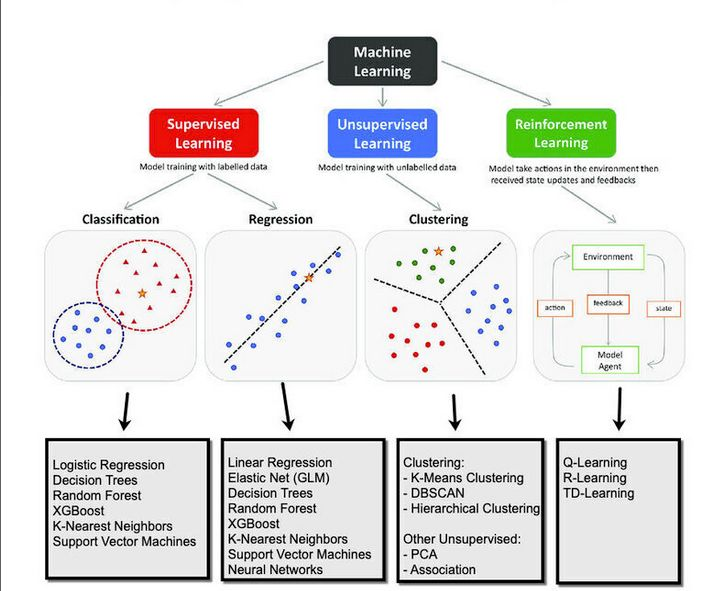

The three types of machine learning and the algorithms in each type

| Type | What the machine is given | What it learns to do | Everyday analogy |
| --- | --- | --- | --- |
| Supervised | inputs with the correct answers (labels) | predict the answer for new inputs | a student learning with an answer key |
| Unsupervised | inputs only, no answers | discover groups and structure | sorting a mixed box of buttons into piles without being told the categories |
| Reinforcement | rewards and penalties after actions | choose actions that earn the most reward | training a dog with treats |

Why three types? Because real situations differ in what is available. If a hospital has past patients with confirmed diagnoses, use supervised learning. If a shop has customer purchase records with no categories, use unsupervised learning. If a robot must learn to walk and the only feedback is whether it fell over, use reinforcement learning.

A college has three jobs:

1. Predict pass or fail from past records with known results.

2. Make study groups from student interests. There are no fixed group names.

3. A program picks quiz questions. It gets points when a student continues to answer, and learns a better order.

Explanation

Job 1 has correct answers, so it uses supervised learning.

Job 2 has no correct answers, so it uses unsupervised learning.

In job 3, the program acts and gets points, so it uses reinforcement learning.

The three jobs give three kinds of feedback. So they need three kinds of learning.

A fruit shop has three problems:

1. It has fruit photos with the label "ripe" or "unripe". It wants to label new photos.

2. It has shopping records with no labels. It wants to find groups of similar buyers.

3. A program changes the price each day. After each day, it sees the profit.

Explanation

Ask one question: what feedback does the machine get?

In problem 1, each example has the correct answer. This is supervised learning.

In problem 2, there are no answers. This is unsupervised learning.

In problem 3, the program acts first and then gets a score (the profit). This is reinforcement learning.

## 2.2Supervised learning

In supervised learning every training example comes with the right answer, called the **label**. The labels act like a teacher marking homework: after each guess the model is told how wrong it was and corrects itself.

[figure not shown]

Supervised learning: labelled examples train a model that can then label new data

### How it works, step by step

1. Collect examples where both the input features and the correct output are known (for example, house size, location and bedrooms with the actual selling price).
2. Feed them to a learning algorithm, which builds a model that links inputs to outputs.
3. Test the model on examples it has not seen, to check it really learned the pattern.
4. Use it on brand-new inputs where the answer is unknown.

Supervised problems come in two flavours depending on the type of answer: **classification** (the answer is a category) and **regression** (the answer is a number). The next section explains how to tell them apart.

The word "supervised" simply means that the correct answers supervise the learning. The big practical cost of supervised learning is that someone has to produce those labels, often by hand, which can be slow and expensive.

We want to predict an auto fare. The past rides are: 2 km cost 50 rupees, 4 km cost 80 rupees, and 6 km cost 110 rupees.

Explanation

For each extra 2 km, the fare goes up by 30 rupees. So 1 km adds 15 rupees.

For 2 km, the distance part is 2 x 15 = 30. The fare is 50, so the starting charge is 20.

The rule is: fare = 15 x distance + 20. For 10 km, it predicts 170 rupees.

The past fares are the labels. A 10 km ride is longer than all past rides, so we can trust this prediction less.

## 2.3Classification versus regression

Ask one question about the answer you want: **is it a category or a number on a scale?**

|  | Classification | Regression |
| --- | --- | --- |
| Goal | predict a class label | predict a continuous numerical value |
| Output | Spam / Not spam, Cat / Dog, 0 / 1 | price, temperature, sales figure |
| Typical questions | Is this email spam? Which animal is in the image? Will this patient have diabetes? | What will this house sell for? What will tomorrow's temperature be? |
| Metrics | accuracy, precision, recall, F1, confusion matrix | MAE, MSE, RMSE, R-squared |
| Algorithms | Logistic Regression, KNN, Decision Tree, Random Forest, SVM, Naive Bayes, Neural Networks | Linear Regression, Polynomial Regression, Regression Trees, SVR |

Why do the metrics differ? In classification an answer is simply right or wrong, so we count mistakes. In regression a prediction of 98 when the truth is 100 is nearly right, while 40 is badly wrong, so we must measure how far off the number is.

A student gets 80 marks. We look at two kinds of prediction.

Classification: the model says "Fail", but the student passed.

Regression: one model predicts 78, and another model predicts 40.

Explanation

In classification, "Fail" is wrong. We count wrong answers and note the type of each mistake.

In regression, neither number is exactly 80. But 78 is wrong by only 2, and 40 is wrong by 40.

A simple count calls both numbers wrong. So regression must measure the size of each error.

Assuming Logistic Regression is a regression algorithm because of its name. It is a **classification** method: it calculates a probability between 0 and 1 (for example 0.83 chance of spam), and then a threshold such as 0.5 turns that probability into a class.

### Applications of supervised learning

Spam detection, recognising objects in images, medical diagnosis and credit-risk prediction (classification); house-price prediction, stock and sales forecasting (regression).

We have data about one student. Question A: will the student pass? Question B: what mark will the student get?

A football shirt has the number 20.

Explanation

Question A is classification, because the answer is a group: pass or fail.

Question B is regression, because the answer is a number on a scale. A mark of 72 is closer to 75 than to 40.

A shirt number is only a name. Number 20 is not two times number 10. So a prediction of the shirt number is classification.

Look at the meaning of the answer, not only at whether it is a number.

## 2.4Unsupervised learning

Here the data has **no labels**. Nobody tells the machine what the right answer is; it must find structure by itself, such as which items resemble each other.

[figure not shown]

Unsupervised learning: the algorithm groups raw data without being told the categories

There are two main jobs:

- **Clustering:** put similar items in the same group. Algorithms: K-Means, Hierarchical clustering, DBSCAN.
- **Dimensionality reduction:** describe the data with fewer features while keeping the important information. Algorithms: PCA, t-SNE.

### Typical use cases

- **Customer segmentation:** group shoppers by buying behaviour so each group gets suitable offers.
- **Anomaly detection:** an item that fits no group (an unusual transaction, a faulty part) stands out.
- **Association and recommendations:** "customers who bought X also bought Y".
- **Topic discovery:** find the themes running through thousands of documents.

Why use it? Labels are costly, and sometimes nobody even knows what the categories should be. Unsupervised learning is how you discover them. The trade-off is that without answers you cannot score "accuracy" in the usual way; a human has to judge whether the groups make sense.

A music app knows what songs people play, but it has no names for types of listeners.

A clustering method finds two groups. One plays calm songs at night. The other plays fast songs in the morning.

Explanation

We cannot start with supervised learning, because there are no labels.

Clustering groups people with similar habits.

A person must decide whether the groups are useful. If they are, the person can give them names. These names can become labels for later work.

Six customers spend these amounts each month: 200, 250, 300, 5000, 5200 and 5500 rupees. The data has no labels.

Explanation

We can see two groups: {200, 250, 300} and {5000, 5200, 5500}.

Numbers in the same group are close to each other. They are far from the numbers in the other group.

A clustering method uses this closeness to make groups. It does not know what the groups mean. A person can name them "low spending" and "high spending".

## 2.5Reinforcement learning

Some problems have no dataset of correct answers at all. A robot learning to walk, or a program learning to play Go, can only try things and see what happens. Reinforcement learning (RL) is built for this.

The agent acts; the environment responds with a new situation and a reward.

The **agent** (the learner) takes an **action** in an **environment**. The environment returns a new **state** and a **reward** (positive for good results, negative for bad). The agent's goal is to learn a strategy that collects the largest total reward over time. Learning is by trial and error, exactly like training a dog with treats.

**Examples:** game-playing programs such as AlphaGo, robots learning to move, and decision systems in autonomous driving. Algorithms include Q-Learning and TD-Learning.

The key difference from supervised learning: in RL nobody says which action was correct; the feedback is only a reward that may arrive late. Winning a chess game gives one reward after dozens of moves, and the agent must work out which moves deserved the credit.

A program must move to a goal on a 3 x 3 board with one pit. A normal move gives -1 point. A move into the pit gives -10. The move that reaches the goal gives +10.

Explanation

No one tells the program the correct move. It tries moves and receives points.

A path of 4 moves has three normal moves and one goal move. The total is -3 + 10 = 7.

A path of 6 moves has five normal moves and one goal move. The total is -5 + 10 = 5.

The program wants the highest total. So after many tries, it can learn to take short paths that avoid the pit.

## 2.6Pattern recognition versus prediction, and batch versus online learning

### Pattern recognition and prediction

These two words describe two stages of the same process. **Pattern recognition** is the learning stage: the algorithm studies training data and finds regularities, such as "emails containing the word *free* are often spam". **Prediction** is the using stage: the model applies what it learned to new, unseen data to make an informed guess. A model recognises patterns in old data in order to predict on new data.

### Batch (offline) and online (incremental) learning

These describe **how** a model is trained.

|  | Batch learning | Online learning |
| --- | --- | --- |
| Training | on the whole dataset at once | step by step, one example or a small group at a time |
| New data | model must be retrained from scratch on old plus new data | model simply updates itself with the new examples |
| Cost | heavy computing each time | light and quick |
| Best for | data that rarely changes, enough computing power | streaming data (stock prices), data too big for memory, patterns that drift over time |

A video app studies old data. Many people who watch cricket in the evening later watch the highlights. Today, it suggests highlights to a new viewer. Then it sees whether the viewer clicks or skips, and updates itself.

Explanation

The app finds a habit in old data. This is pattern recognition.

It uses the habit to guess what the new viewer likes. This is prediction.

It updates after each click or skip and does not train again on all old data. This is online learning.

If it trains again on the full history once a month, that is batch learning.

## 2.7Exam questions and model answers: Chapter 2

Q1. Differentiate between supervised and unsupervised learning.

Supervised learning trains on labelled data, where each input has a known correct output, and learns to predict the output for new inputs; it is used for classification and regression, for example spam detection and house price prediction. Unsupervised learning uses unlabelled data and discovers hidden structure such as clusters, used for customer segmentation, anomaly detection and dimensionality reduction. In supervised learning a "teacher" (the labels) exists; in unsupervised learning it does not.

Q2. Compare classification and regression.

Classification predicts a discrete category (spam or not spam) and is evaluated with accuracy, precision, recall, F1 and the confusion matrix. Regression predicts a continuous number (a price) and is evaluated with MSE, RMSE, MAE and R-squared. Classification asks "which class?" while regression asks "how much?".

Q3. Give applications of supervised and unsupervised learning.

Supervised: spam detection, image recognition, medical diagnosis, credit scoring, house and stock price prediction. Unsupervised: customer segmentation, anomaly or fraud detection, dimensionality reduction with PCA, market-basket recommendations, topic modelling.

Q4. What is reinforcement learning?

It is learning by interaction. An agent takes actions in an environment and receives rewards or penalties; over many trials it learns the policy that maximises total reward. Examples are game playing, robotics and autonomous driving.

Q5. Differentiate between prediction and pattern recognition.

Pattern recognition is discovering regularities in the training data; it is the learning part of ML. Prediction is using the learned patterns to produce an output for new, unseen data. Recognition builds the knowledge; prediction applies it.

Q6. Differentiate between batch and online learning.

Batch learning trains on the entire dataset at once and must be retrained from scratch to include new data, which is costly but suits stable data. Online learning trains incrementally on a stream of examples, updating without full retraining, which suits continuously arriving data, huge datasets, or changing patterns.

Chapter 3

# Data: The Fuel of Machine Learning

Datasets, features, cleaning, scaling and splitting. Most of a real project's time goes here.

## 3.1Dataset, features and labels

A model learns only from the data it is given, so understanding how data is organised is the first practical skill.

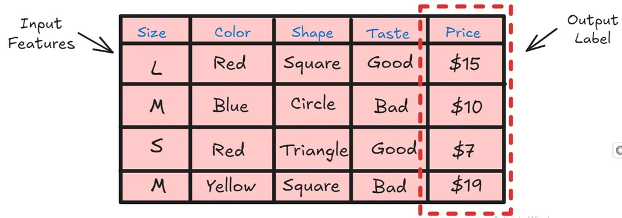

A dataset: input features (Size, Color, Shape, Taste) and an output label (Price)

- A **dataset** is a structured collection of data, usually a table.
- Each **row** is one **sample** (one house, one customer, one email).
- Each **column** is a **feature**: one measurable property of the sample (size, age, number of words).
- The column we want to predict is the **label** or **target** (the price). Only supervised learning has labels.
- All the features of one row, written as a list of numbers, form a **feature vector**.

Loan data: Sample 1 has Age 25, Income 40,000 and Loan Approved = Yes. Sample 2 has Age 50, Income 90,000 and Loan Approved = No. The **features** are Age and Income. The **label** is Loan Approved. The model's job is to learn how age and income relate to the decision.

The dataset is the model's only "experience". Its quality, size and relevance set a ceiling on how good the model can ever be. No algorithm can learn a pattern that the data does not contain.

A small table helps to predict exam results. Its columns are study hours, attendance and result.

Student 1: 6 hours, 90 percent, Pass.

Student 2: 1 hour, 40 percent, Fail.

Explanation

Each student is one sample, which is one row.

Study hours and attendance are features, because we use them as inputs.

Result is the label, because it is the answer that we want to predict.

The feature vector (list of inputs) of student 1 is (6, 90).

## 3.2Data collection and representation

**Collection** is the first step of every ML project and the one that matters most. Data may come from databases, files (CSV, JSON), APIs, sensors, or web scraping. It must be relevant to the problem, large enough, and free from unfair bias, because the model will inherit whatever is in it.

**Representation** means arranging the data so an algorithm can use it. The standard form is a table: rows for observations, columns for features, and one column for the label.

### Everything must become numbers

A model does arithmetic, so every feature must be numeric. Text, categories and images need converting:

- **Categories:** a column City with values Kolkata, Delhi, Mumbai is turned into three yes/no columns (City_Kolkata, City_Delhi, City_Mumbai). This is called **one-hot encoding**. A plain code of 1, 2, 3 would wrongly suggest that Mumbai is "greater" than Delhi.
- **Images:** an image is a grid of pixel brightness numbers.
- **Text:** words are converted to numbers (counts, or learned vectors).

A shirt table has two columns. Size is Small, Medium or Large. Color is Red, Green or Blue. A model needs numbers.

For size, use Small = 1, Medium = 2 and Large = 3.

For color, use Red = (1, 0, 0), Green = (0, 1, 0) and Blue = (0, 0, 1). This is one-hot encoding (one yes or no column for each color).

Explanation

Sizes have a natural order, so 1, 2 and 3 can keep that order.

Colors have no order. If Red = 1 and Blue = 3, a model can treat Blue as bigger than Red.

With one-hot encoding, no color is bigger than another color.

## 3.3Data cleaning: what goes wrong in real data

Real data is messy. Cleaning means repairing it before learning, and it typically takes about 80 percent of a data practitioner's time.

| Problem | Example | Why it harms |
| --- | --- | --- |
| Missing values | blood pressure not recorded | many algorithms cannot even run with blanks |
| Errors and noise | age typed as 250 | teaches wrong patterns |
| Inconsistent formats | "New York", "NY", "N.Y."; age written as "twenty-five" | one thing looks like several different things |
| Outliers | one salary a hundred times larger than the rest | drags averages and distorts training |
| Duplicates | same customer entered twice | gives that case extra weight and can leak between train and test sets |
| Irrelevant data | roll number used to predict marks | adds noise without information |

"Garbage in, garbage out." A model has no common sense to ignore bad data; it will faithfully learn whatever it is shown. Poor data causes inaccurate predictions, biased outcomes, poor generalisation, and wasted effort tuning a model that never had a chance.

We train a fruit model with 100 apple photos. By mistake, 30 of them have the label "orange".

Explanation

The training method treats each label as correct.

So the model learns that many apples are oranges.

A bigger model can copy these wrong labels even more closely. The direct fix is to correct the labels.

Find the problems in these rows (name, age, city, marks):

Row 1: Asha, 19, Delhi, 78.

Row 2: Asha, 19, Delhi, 78.

Row 3: Ravi, 190, delhi, 65.

Row 4: Meena, 20, Mumbai, blank.

Explanation

Rows 1 and 2 look like duplicates. Compare their student ID numbers first, because two students can have the same details.

In row 3, an age of 190 is an error. Also, "delhi" and "Delhi" are the same city in two spellings.

In row 4, the mark is missing.

These are different problems, so each one needs a different fix. Look at the data before you choose the fix.

## 3.4Handling missing values and outliers

### Missing values

- **Remove the rows** with blanks. Simple, but if many rows have a blank you lose a lot of data.
- **Remove the column** if most of its values are missing, since it carries little information.
- **Impute** (fill in) with a typical value: the mean, median or mode of that column.

Ages are 22, 25, 24, ?, 23, and one extra patient aged 90 is in the data: 22, 25, 24, 90, 23 with one blank. The mean of the known values is 36.8, which is not a typical age here at all because the 90 pulled it up. The median is 24, a sensible fill. This is why **the median is preferred when outliers exist**, while the mean is fine for well-behaved data. For a category such as city, fill with the **mode** (the most common value).

### Outliers

An outlier is a value far from the rest. First decide whether it is an **error** (age 250) or a **real extreme** (a genuine fraud case, which is exactly what you want to catch). A common detection rule: compute Q1 and Q3 (the 25th and 75th percentiles) and IQR = Q3 - Q1; values below Q1 - 1.5 x IQR or above Q3 + 1.5 x IQR are flagged as outliers.

- **Remove** true errors, but be careful: deleting a real extreme throws away information.
- **Transform** the feature, for example with a logarithm, which shrinks huge values.
- **Use robust scaling**, which relies on the median and IQR so outliers hardly matter.

Delivery times in minutes are: 10, 11, 12, 13, 14, 15, 16, 17 and 60.

Q1 is 12 and Q3 is 16. About one quarter of the values are below Q1, and about three quarters are below Q3.

Explanation

The IQR is the width of the middle half: 16 - 12 = 4.

Lower limit: 12 - 1.5 x 4 = 6. Upper limit: 16 + 1.5 x 4 = 22.

Only 60 is outside these limits, so we mark it as an outlier.

The mark does not prove that 60 is wrong. A typing error needs a correction. A real delay from a flood is true data.

Different software can give slightly different quartile values.

## 3.5Feature selection

Not every column helps. Feature selection means keeping the useful features and dropping the rest. Think of packing for a trip: carrying everything makes the bag heavy and slows you down, and most of it is not needed.

### Why it is worth doing

- **Better accuracy:** irrelevant features are noise that can mislead the model.
- **Less overfitting:** fewer features give fewer ways to fit random patterns.
- **Faster training** and lower memory use.
- **Easier explanation:** a model using five features is easier to understand than one using five hundred.

### Three families of methods

| Method | How it works | Examples |
| --- | --- | --- |
| Filter | score each feature on its own relationship with the label, and keep the high scorers; fast and independent of any model | correlation, chi-square |
| Wrapper | try different feature subsets by actually training a model and measuring performance; accurate but slow | forward selection (add one at a time), backward elimination (remove one at a time) |
| Embedded | the model selects features while it trains | Lasso, Random Forest feature importance |

**Example:** in a breast-cancer dataset, the feature `radius_mean` (average cell size) strongly separates benign from malignant cases, while `fractal_dimension` carries little signal, so a selector would keep the first and may drop the second.

We want to predict the price of a house. The columns are: number of rooms, phone number of the owner, area in square meters and area in square feet.

Explanation

The phone number has no useful link to the price. Remove it.

The two area columns give the same fact in two units. Keep only one.

So there are two reasons to remove a column: it does not help, or it repeats another column. The number of rooms stays.

## 3.6Feature scaling (normalisation)

Suppose a model sees Age (20 to 70) and Income (20,000 to 200,000). Algorithms that measure distances or use gradient descent treat numbers literally, so a difference of 50,000 in income swamps a difference of 20 in age, even though both could matter equally. Scaling puts all features on a comparable range so each gets a fair say.

| Technique | Formula | Result and when to use |
| --- | --- | --- |
| Min-Max scaling | (x - min) / (max - min) | every value between 0 and 1; simple, but sensitive to outliers |
| Standardisation (Z-score) | (x - mean) / standard deviation | mean 0 and standard deviation 1; the usual default |
| Robust scaling | (x - median) / IQR | safe when outliers are present |
| Max-Abs scaling | x / largest absolute value | good for sparse data that is already centred |

Exam marks 40, 70 and 100. Min = 40 and max = 100, so the range is 60. Min-max scaling: 40 becomes (40-40)/60 = 0; 70 becomes 30/60 = 0.5; 100 becomes 60/60 = 1. The order and spacing are preserved; only the units changed.

**Which algorithms need scaling?** KNN and SVM compute distances; neural networks and linear models learn by gradient descent, which converges much faster when features share a scale. Decision trees and Random Forests split on one feature at a time, so they do not need it.

Three people are listed as (age, yearly income in rupees): A = (25, 50,000), B = (60, 50,500), C = (26, 52,000). Who is closer to A: B or C?

KNN uses the straight-line distance to decide.

Explanation

Without scaling, the distance from A to B is about 501, and from A to C about 2,000. So B looks closer, although B is 35 years older. The large income numbers control the result.

To scale, divide each age by 40 and each income by 100,000. These two numbers are the assumed ranges.

Now the distance from A to B is about 0.88, and from A to C about 0.03. C is much closer.

A decision tree asks one question about one feature, such as "Is age above 30?". If we change the scale, we can change the cut-off in the same way. So trees do not need this step.

Three scores are 50, 60 and 70. We want to standardize them, which means to put them on a common scale.

Explanation

The mean (average) is 60.

The standard deviation (typical spread around the mean) of these scores is 8.16.

For 50: (50 - 60) / 8.16 = -1.22. For 60, the result is 0. For 70, it is +1.22.

A minus sign means below average. A plus sign means above average. The results do not have to stay between 0 and 1.

In a real project, find the mean and the standard deviation from the training data only. Then use the same two numbers for the test data.

## 3.7Splitting data: training, validation and test sets

A model can always be made to score well on data it has already seen, simply by memorising it. What we actually care about is performance on **new** data. So before training we split the dataset into parts that play different roles.

A common split. Ratios vary: 70/10/20 and 60/20/20 are both common.

| Set | Used for | Analogy |
| --- | --- | --- |
| Training set (largest part) | the model learns its parameters from it | practice questions |
| Validation set | compare settings (hyperparameters) and detect overfitting while developing | a mock test |
| Test set | one final, unbiased measurement of how the finished model performs on unseen data | the real exam, taken once |

Why a separate test set? If you tune the model until it does well on a dataset, that dataset has quietly influenced the model, so the score is optimistic. The test set must stay untouched until the very end, like an exam paper that students have never seen. Using test data during training is called **data leakage** and makes results look better than they will be in real life.

Twenty students guess every answer in a test with 10 true or false questions. We pick the highest score and say that it shows the skill of that student.

Explanation

With 20 people, one of them can easily get a high score by luck.

We picked that student because of this score. So the score makes the skill look better than it is.

A new test gives a fairer measure. In the same way, if we pick the best model on one set of data, its score there can be too high. So we keep test data for the end.

### How a split program works

1. Take the feature table X and the label list y.
2. Decide the test fraction, for example 0.2.
3. **Shuffle** the rows randomly. If the file is sorted (all "No" rows first), an unshuffled split would put only "Yes" rows in the test set.
4. For classification, **stratify**: keep the same class proportions in each part. With 5 percent fraud cases, a random split might otherwise leave no fraud at all in the test set.
5. Cut: the first 80 percent of the shuffled rows go to training, the rest to testing.
6. Return X_train, X_test, y_train, y_test.

```
from sklearn.model_selection import train_test_split
X_train, X_test, y_train, y_test = train_test_split(
    X, y, test_size=0.2, random_state=42, stratify=y)
```

`random_state=42` fixes the random shuffle, so everyone gets the same split and results can be repeated.

We have 1,000 payments, and 50 of them (5 percent) are fraud. We split them into 70, 10 and 20 percent parts. We use a stratified split, which keeps the same share of fraud in each part.

Explanation

Training data: 700 rows with 35 frauds.

Validation data: 100 rows with 5 frauds.

Test data: 200 rows with 10 frauds.

Each part has 5 percent fraud, so no part has too few frauds by chance.

The train_test_split call in this lesson makes two parts. To get three parts, use it again on one of the two parts.

## 3.8Exam questions and model answers: Chapter 3

Q1. What is a dataset? What are features and labels?

A dataset is a structured collection of data used for learning; rows are samples and columns are features. A feature is a measurable property used as input, such as area or number of bedrooms. A label (target) is the output the model should predict, such as the price. In supervised learning the model learns the relationship between features and label.

Q2. Explain data collection and representation.

Collection is gathering raw data from databases, files, APIs, sensors or scraping; its quality limits the model's quality. Representation arranges data as a table: rows are observations, columns are features, one column is the label. Non-numeric data such as categories, text and images must be converted into numbers.

Q3. What are the common data quality issues and how are missing values and outliers handled?

Issues include missing values, noise, inconsistent formats, outliers, duplicates and irrelevant data. Missing values are handled by removing rows or columns, or imputing with mean, median or mode (median is preferred with outliers). Outliers can be removed if they are errors, reduced by transformations such as a logarithm, or handled with robust scaling.

Q4. Why is feature selection important?

It removes irrelevant or redundant features, which improves accuracy, reduces overfitting, lowers computation and memory use, and makes the model easier to interpret.

Q5. Describe common feature scaling techniques and why scaling is needed.

Min-Max scaling maps values to 0 to 1; standardisation gives mean 0 and standard deviation 1; robust scaling uses the median and IQR; max-abs scaling divides by the maximum absolute value. Scaling is needed because distance-based and gradient-based algorithms would otherwise be dominated by features with large numeric ranges.

Q6. What are the training, validation and test sets?

The training set is used to learn parameters; the validation set is used during development to tune hyperparameters and detect overfitting; the test set is held back and used once at the end for an unbiased estimate of performance on unseen data. A common split is 60/20/20 or 70/10/20.

Q7. Write the logic of a train/test split program.

Take X and y, choose the test fraction, shuffle the data randomly (and stratify by class for classification), allocate the first (1 - test fraction) of the shuffled rows to training and the rest to testing, and return X_train, X_test, y_train, y_test. The same shuffled order must be applied to X and y so each row keeps its label.

Chapter 4

# Models, Fitting and Generalisation

What the common algorithms do, and why a model that scores well in practice can still fail in the real world.

## 4.1Common models explained in plain words

You do not need the mathematics of every algorithm at first. You do need to know the **idea** behind each one, so you can say what it does and when it is a good choice.

### Classification models

- **K-Nearest Neighbours (KNN).** To classify a new point, find the K training points closest to it and take a vote. If the 5 nearest houses to a new house are all in the "expensive" group, call the new one expensive too. The idea is "you are like your neighbours". It needs no training time, but it is slow on big data and needs scaled features, because "closest" depends on distance.
- **Decision Tree.** A flowchart of yes/no questions ("income above 50,000?" then "age below 30?") that ends in an answer at each leaf. Easy to read and explain, but a deep tree memorises the training data (overfits).
- **Random Forest.** Many different decision trees, each trained on a random part of the data, vote on the answer. One tree can be wrong in its own way; a crowd of different trees averages out those errors, so the forest is more reliable.
- **Support Vector Machine (SVM).** Draws the dividing line between two classes so that the gap (margin) between the line and the nearest points on each side is as wide as possible. A wide margin means the boundary is not fragile.
- **Naive Bayes.** Uses probability and Bayes' theorem: given the words in an email, how likely is spam? It is called naive because it assumes features are independent, which is not strictly true but works surprisingly well.
- **Logistic Regression.** Computes a weighted sum of the features and squeezes it into a probability between 0 and 1.
- **Neural Networks.** Layers of simple units whose connection strengths are learned. Covered in detail in the deep learning chapters.

### Regression models

- **Linear Regression:** fits a straight line (or flat plane) through the data.
- **Polynomial Regression:** fits a curve, for relationships that bend.
- **Regression Trees:** like decision trees, but each leaf holds a number (the average of the examples reaching it).
- **Support Vector Regression (SVR):** the SVM idea applied to predicting numbers.

There is no single best model for all data (the "no free lunch" idea). The choice depends on the amount of data, whether the relationship is straight or curved, how important it is to explain the result, and how much computing is available. Trees are easy to explain; neural networks excel on images and text but need lots of data.

Job 1: tell a bank customer why the bank refused a loan.

Job 2: name objects in a very large set of photos.

Explanation

For job 1, a small decision tree is a good option, because a person can follow each question to the decision.

For job 2, a CNN is a strong option, because it learns image patterns from many photos.

The two jobs need different things, so one model is not best for both. Compare possible models on validation data.

KNN with K = 3 must decide if a new fruit is an apple or an orange. K is the number of neighbors that vote.

The three closest known fruits are: an apple at distance 1.0, an orange at 1.4 and an apple at 1.5.

Explanation

There are two votes for apple and one vote for orange. So the answer is apple.

With K = 1, only one fruit decides. If its label is wrong, the answer can be wrong.

With a very large K, fruits that are far away also vote. So we must choose K with care.

## 4.2Parameters and hyperparameters

Two kinds of numbers control a model, and students often mix them up.

| Parameters | Hyperparameters |
| --- | --- |
| Learned **from the data** during training | Set **by us before** training begins |
| Weights and biases of a network; slope and intercept of a fitted line | K in KNN; depth of a decision tree; learning rate; number of layers or neurons; number of clusters in K-Means |
| The algorithm adjusts them automatically | We choose them by trying values and checking performance |

A hyperparameter is a configuration value chosen before training that controls how the model is built or how learning proceeds. It is not learned from the data.

### Why hyperparameters matter

- **They control performance.** A learning rate that is wrong can stop training from ever succeeding (shown in the next chapters).
- **They control complexity.** Tree depth or number of neurons decides how flexible the model is, and therefore whether it underfits or overfits.
- **They define how learning happens**, such as which optimiser or activation function is used.

Because the training data cannot tell us the best hyperparameters, we try different values and compare the results on the **validation set**. **Grid search** tries every combination from a list; **random search** tries random combinations and is often just as good and faster.

Analogy: baking a cake. The oven temperature and baking time are hyperparameters, chosen before baking. How the batter transforms is what happens during the process, like parameters being learned.

A line predicts a price: price = w x area + b.

We also try KNN with K = 1, 5 and 25. The validation accuracy is 78, 86 and 81 percent. These results are made up.

Explanation

Training finds w and b from the data. So w and b are parameters.

A person or a search program chooses the K values to try before each training run. So K is a hyperparameter.

We select K = 5, because it gives the best validation result.

To tell them apart, ask: does training learn this value from the data?

## 4.3Underfitting and overfitting

The goal of ML is **not** to do well on the training data. It is to do well on data the model has never seen. Two opposite failures stop that from happening.

[figure not shown]

The same eight points fitted by a model that is too simple, well balanced, and too complex.

### Underfitting: too simple

The model is too weak to capture the real pattern. Imagine fitting a straight line through points that clearly form an arch. The line will be wrong everywhere, on the training data **and** on new data. Symptom: **high error on both training and test data**.

### Overfitting: too complex

The model is so flexible that it passes through every training point, including the random noise. The twisting curve on the right of the figure hits each dot perfectly, but between the dots it swings wildly, so on new data it does badly. Symptom: **very low training error but high test error**.

|  | Underfitting | Good fit | Overfitting |
| --- | --- | --- | --- |
| Model complexity | too low | about right | too high |
| Training error | high | low | very low |
| Test error | high | low | high |
| Example | straight line on curved data | smooth curve through the trend | very deep decision tree; high-degree polynomial |

The exam analogy: **underfitting** is not studying at all, so you fail both practice and real exam. **Overfitting** is memorising the exact answers to the practice questions: perfect on practice, lost when the real paper words things differently. **A good fit** is understanding the concepts, so you do well on both.

How to diagnose: compare training and test performance. Both poor means underfitting. Training excellent but test poor means overfitting. Both good and close means a good fit.

Three models have these errors. The numbers are made up.

Model A: 30 percent on training data and 32 percent on test data.

Model B: 1 percent on training data and 25 percent on test data.

Model C: 8 percent on training data and 10 percent on test data.

Explanation

Model A is wrong often on both sets of data. It underfits.

Model B does very well on training data but much worse on new data. It overfits.

Model C has low errors that are close together. It is a good fit.

B has the lowest training error, but C works better on new data. In a real project, use validation data to compare models. Keep the test data for the end.

## 4.4The bias-variance trade-off and generalisation

Bias and variance are the two sources of error behind underfitting and overfitting.

- **Bias** is error from wrong or over-simple assumptions. A high-bias model always misses in the same direction, for example by insisting on a straight line. High bias leads to **underfitting**.
- **Variance** is error from being too sensitive to the particular training sample. A high-variance model changes drastically if you give it slightly different data, because it has learned the noise. High variance leads to **overfitting**.

The **trade-off**: making a model more complex reduces bias (it can capture more patterns) but increases variance (it can also capture more noise). Making it simpler does the reverse. The best model sits at the bottom of the test-error curve, where the combined error is smallest.

Archery picture. High bias: all arrows cluster tightly but away from the bullseye. High variance: arrows are scattered all around. Low bias and low variance: arrows tightly grouped on the bullseye.

### Generalisation

**Generalisation** is a model's ability to perform well on new, unseen data after learning from a finite training set. It is the real goal. An overfit model generalises poorly because it memorised; an underfit model generalises poorly because it never learned the pattern; a good model learned the underlying pattern and performs well on both. The test-set score is the measure of generalisation.

The true temperature is 30 degrees on each of four days.

Person P predicts 25, 25, 26 and 24. Person Q predicts 22, 38, 25 and 35.

Explanation

P always stays near 25, which is 5 degrees too low. This is like high bias: the same kind of mistake again and again.

The average of Q is 30, but the single predictions jump a lot. This is like high variance.

This is only a picture of the idea. In ML, variance tells how much predictions change when we train with different data.

## 4.5How to prevent overfitting (and fix underfitting)

### Against overfitting

- **More training data:** noise averages out and real patterns stand out.
- **Simpler model or fewer features:** less freedom to fit noise.
- **Regularisation:** add a penalty to the loss for large weights. Large weights produce the sharp, wiggly curves of overfitting, so penalising them keeps the curve smooth. The loss becomes: error + (strength) x (size of the weights).
- **Cross-validation:** a more reliable way to estimate performance. In **k-fold** cross-validation the data is cut into k parts (say 5). The model is trained on 4 parts and validated on the 5th, and this is repeated so every part is used once as validation. The 5 scores are averaged. This reduces the chance that one lucky or unlucky split fools you.
- **Pruning:** cut back the branches of a decision tree.
- **Early stopping:** stop training when the validation error begins to rise, even though training error is still falling.
- **Dropout** (neural networks): randomly switch off some neurons during training so the network cannot rely on any single path.

### Against underfitting

Use a more flexible model, add more informative features, train for longer, or reduce regularisation.

We use 5-fold cross-validation. We cut the data into 5 parts, and each part gets one turn as validation data.

The five accuracy results are 80, 82, 78, 84 and 76 percent.

Explanation

The total is 400, so the average is 400 / 5 = 80 percent.

With only one split, we can get 76 or 84 by chance. The average of five results is usually a steadier estimate.

Cross-validation does not stop overfitting by itself. It helps us to find it and to choose better model settings.

## 4.6Exam questions and model answers: Chapter 4

Q1. Explain underfitting and overfitting with examples.

Underfitting occurs when a model is too simple to capture the pattern in the data; it has high error on both training and test sets, for example a straight line fitted to curved data. Overfitting occurs when a model is too complex and learns the noise in the training data; it has very low training error but high test error, for example a very deep decision tree or a high-degree polynomial. By analogy, underfitting is not studying, overfitting is memorising the practice paper, and a good fit is understanding the subject.

Q2. What is the bias-variance trade-off?

Bias is the error from over-simplified assumptions and causes underfitting; variance is the error from sensitivity to the training sample and causes overfitting. Increasing model complexity lowers bias but raises variance, and decreasing complexity does the opposite. The aim is the balance that gives the lowest error on unseen data.

Q3. What is meant by model generalisation?

Generalisation is the ability of a trained model to perform accurately on new, unseen data. A model that has learned the true underlying pattern generalises well; overfit and underfit models generalise poorly. It is measured by performance on the test set.

Q4. Why are hyperparameters important and how are they chosen?

Hyperparameters such as learning rate, tree depth and number of layers control model complexity and the learning process, and so strongly affect accuracy and overfitting. Since they are not learned from data, they are chosen by trying different values, using grid or random search, and comparing performance on the validation set.

Q5. List methods to prevent overfitting.

Use more data, simplify the model, select fewer features, apply regularisation, use cross-validation, prune trees, use early stopping, and apply dropout in neural networks.

Q6. Differentiate between parameters and hyperparameters.

Parameters (weights, biases) are learned from data during training. Hyperparameters (learning rate, K, depth) are set before training and control how the model learns or how complex it is.

Chapter 5

# Measuring Performance

How to tell whether a model is actually good, and why a single number such as accuracy can mislead.

## 5.1Accuracy and why it can mislead

Accuracy = number of correct predictions / total number of predictions.

Accuracy is easy to understand, and for balanced data it is a reasonable first measure. But look at what happens when one class is rare.

A bank has 10,000 transactions of which only 100 (1 percent) are fraud. A lazy model that answers "not fraud" for everything is correct 9,900 times, giving 99 percent accuracy, yet it catches zero frauds and is completely useless. Accuracy hides the fact that all the mistakes are on the class we care about.

On imbalanced data, and wherever different mistakes have different costs, we need measures that look at the types of error separately. That is the job of the confusion matrix and of precision, recall and F1.

A factory makes 1,000 bulbs, and 20 are bad. A useless program says "good" for every bulb.

Explanation

It is correct for the 980 good bulbs. So its accuracy is 980 / 1000 = 98 percent.

But it finds none of the 20 bad bulbs.

There are many more good bulbs than bad bulbs, so accuracy hides this failure.

Always compare your model with a simple method that gives the most common answer every time.

## 5.2The confusion matrix

A confusion matrix is a small table that counts how many predictions fall into each combination of **actual** and **predicted** class. For a yes/no problem there are four possible outcomes.

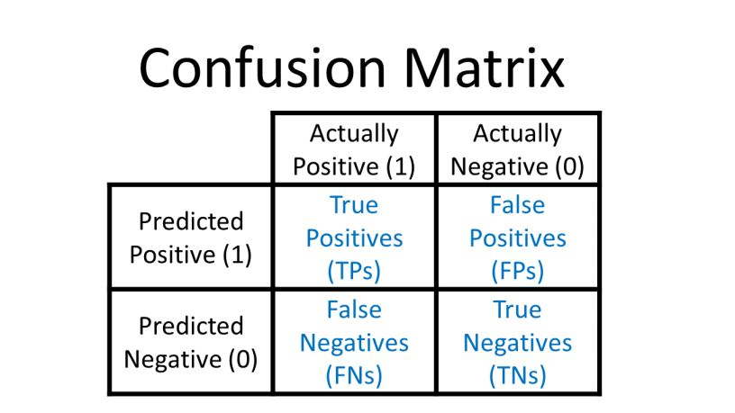

Layout of a confusion matrix: actual class against predicted class

| Term | Meaning | Example (disease test) |
| --- | --- | --- |
| **TP** True Positive | predicted positive, actually positive | sick patient correctly told "sick" |
| **TN** True Negative | predicted negative, actually negative | healthy patient correctly told "healthy" |
| **FP** False Positive (Type I error) | predicted positive, actually negative | healthy patient wrongly told "sick": a false alarm |
| **FN** False Negative (Type II error) | predicted negative, actually positive | sick patient wrongly told "healthy": a missed case |

Memory trick: the second word is what the model **predicted** (Positive or Negative); the first word says whether that prediction was **True** (correct) or **False** (wrong). So a False Positive is a wrong "positive" prediction.

A test is used on 100 people, and 20 of them are sick. The test says "sick" for 25 people. Of these 25, only 18 are really sick.

Explanation

TP (sick, and the test says sick) = 18.

FP (healthy, but the test says sick) = 25 - 18 = 7.

FN (sick, but the test says healthy) = 20 - 18 = 2.

TN (healthy, and the test says healthy). There are 80 healthy people, so TN = 80 - 7 = 73.

The total is 18 + 7 + 2 + 73 = 100. The accuracy is (18 + 73) / 100 = 91 percent.

## 5.3Precision, recall and F1-score

These three measures answer different questions.

Precision = TP / (TP + FP) Recall = TP / (TP + FN) F1 = 2 x Precision x Recall / (Precision + Recall)

- **Precision** asks: of all the cases the model **flagged** as positive, how many really were? It measures how trustworthy a positive prediction is. It is important when false alarms are costly, for example sending a genuine important email to the spam folder.
- **Recall** (sensitivity) asks: of all the **real** positives, how many did the model find? It measures how complete the detection is. It is important when missing a case is costly, for example cancer screening, where a missed patient is far worse than an extra test.
- **F1-score** combines both into one number using the harmonic mean. It is high only when **both** precision and recall are high; if either is poor, F1 is dragged down. It is useful when you need a balance and the classes are uneven.

**Why a harmonic mean and not a simple average?** A model that flags everything as positive has recall 100 percent and terrible precision; the plain average would look acceptable (for example 55 percent). The harmonic mean punishes such lopsidedness and gives a very low score, which is the honest answer.

A model marks all 1,000 emails as spam. Only 10 emails are really spam.

Explanation

Recall = 10 / 10 = 1.00, because the model finds all the spam.

Precision = 10 / 1000 = 0.01, because 990 of its spam marks are wrong.

The simple average is 0.505. This makes the useless model look half good.

F1 = 2 x 0.01 x 1 / 1.01 = about 0.02. This low value shows the problem. F1 stays low when one of the two values is very low.

### The precision-recall trade-off

Most classifiers produce a probability and apply a threshold (often 0.5). If you lower the threshold the model flags more cases: recall rises (fewer missed) but precision falls (more false alarms). Raise the threshold and the reverse happens. You choose the threshold according to which mistake is more costly.

A model gives each payment a fraud score. A higher score means that fraud is more likely.

Scores of the 4 real frauds: 0.95, 0.85, 0.60, 0.40.

Scores of 6 good payments: 0.70, 0.50, 0.45, 0.20, 0.10, 0.05.

The model reports fraud when a score is above the threshold (cut-off point).

Explanation

Threshold 0.80: it reports 2 payments, and both are fraud. Precision = 2/2 = 1.00. Recall = 2/4 = 0.50.

Threshold 0.55: it reports 4 payments, and 3 are fraud. Precision = 3/4 = 0.75. Recall = 3/4 = 0.75.

Threshold 0.35: it reports 7 payments, and 4 are fraud. Precision = 4/7 = 0.57. Recall = 4/4 = 1.00.

A lower threshold finds more frauds, but here it also reports more good payments. When you lower the threshold, recall never goes down. Precision often goes down, but not at every step.

## 5.4Worked example: a spam filter

A spam filter is tested on 10,000 emails. The confusion matrix is:

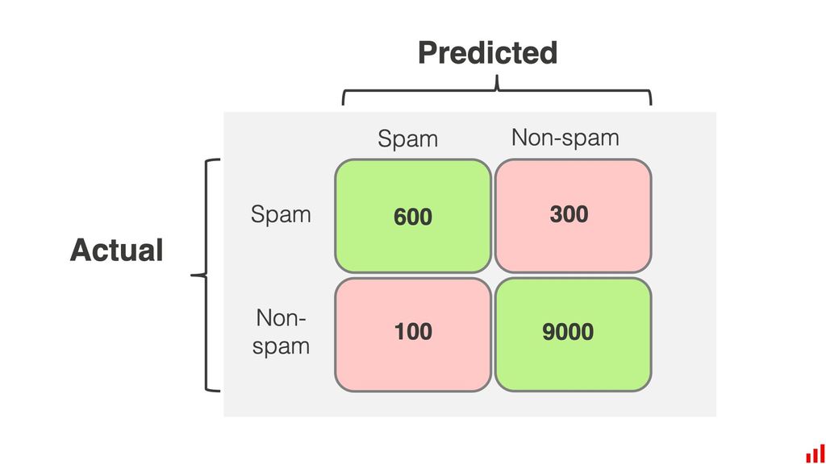

Spam filter results: TP = 600, FN = 300, FP = 100, TN = 9000

TP = 600 (spam caught), FN = 300 (spam missed), FP = 100 (good mail wrongly marked spam), TN = 9000 (good mail correctly kept).

- **Accuracy** = (600 + 9000) / 10,000 = 0.96, that is 96 percent.
- **Precision** = 600 / (600 + 100) = 0.857. When the filter says "spam", it is right 85.7 percent of the time.
- **Recall** = 600 / (600 + 300) = 0.667. It catches only two thirds of all spam.
- **F1** = 2 x 0.857 x 0.667 / (0.857 + 0.667) = 0.75.

Accuracy of 96 percent looks excellent, but one third of the spam still reaches the inbox. Recall reveals what accuracy hid. Always read the confusion matrix, not just the accuracy.

Test a second spam filter, B, on the same emails: 900 spam and 9,100 good.

Filter B: TP = 810, FN = 90, FP = 600, TN = 8500.

Filter A is the filter in this lesson.

Explanation

B: accuracy 93.1 percent, precision 0.57, recall 0.90, F1 0.70.

A: accuracy 96 percent, precision 0.86, recall 0.67, F1 0.75.

B catches more spam: 810 instead of 600. But it also moves more good emails to the spam folder: 600 instead of 100.

The better filter depends on the cost of each mistake. If a lost good email is the worse mistake, A is the safer choice.

## 5.5Regression metrics

In regression a prediction is rarely exactly right, so we measure **how far off** it is. The error for one example is (actual - predicted).

| Metric | What it is | Why use it |
| --- | --- | --- |
| **MAE** Mean Absolute Error | average of \|actual - predicted\| | easy to read: "on average we are off by this much" |
| **MSE** Mean Squared Error | average of (actual - predicted) squared | squaring punishes large errors heavily and gives a smooth curve that gradient descent can follow |
| **RMSE** | square root of MSE | brings the error back to the original units (rupees, degrees) |
| **R-squared** | fraction of the variation in the target that the model explains | 1 is perfect; 0 means no better than always predicting the average |

Actual prices 10, 20, 30; predicted 12, 18, 33. Errors: 2, -2 and 3 (sign does not matter for MAE). MAE = (2 + 2 + 3) / 3 = 2.33. MSE = (4 + 4 + 9) / 3 = 5.67. RMSE = square root of 5.67 = 2.38. For R-squared: the actual mean is 20, total variation = 100 + 0 + 100 = 200, unexplained = 4 + 4 + 9 = 17, so R-squared = 1 - 17/200 = 0.915 (the model explains about 91 percent of the variation).

| Classification metrics | Regression metrics |
| --- | --- |
| Accuracy, precision, recall, F1-score, confusion matrix, ROC-AUC (how well classes are separated across all thresholds) | MAE, MSE, RMSE, R-squared |

Two models predict delivery times for four orders. The numbers below show how many minutes each prediction is wrong.

Model A: 4, 4, 4, 4.

Model B: 0, 0, 0, 16.

Explanation

MAE is the average error. For both models, 16 / 4 = 4.

For RMSE, first square each error. Then find the average. Last, take the square root.

A: the squares add to 64, the average is 16, and RMSE = 4.

B: the square of 16 is 256, the average is 64, and RMSE = 8.

RMSE gives a big mistake more weight. Use it when one very late order is worse than several small delays.

## 5.6The loss function

A loss function (cost function) is a formula that turns the difference between predicted and actual values into a single number: the larger the number, the worse the prediction.

The loss is the model's "mistake meter", and it is what makes automatic learning possible. A model cannot improve unless it knows how wrong it is. Training is the search for the parameters that give the **smallest average loss** over the training data.

- Regression usually uses **Mean Squared Error**.
- Two-class classification uses **Binary Cross-Entropy**.
- Many-class classification uses **Categorical Cross-Entropy**.

### Loss versus accuracy

Accuracy only counts right or wrong, so it changes in jumps and cannot tell the model which direction to move. The loss changes smoothly: a prediction of 0.9 for a true 1 has less loss than 0.6, even though both are "correct". That smoothness lets gradient descent find a direction to improve. We **optimise the loss** but **report the accuracy**.

The correct class is 1. A model gives p, the probability of class 1. The binary cross-entropy loss for this case is -ln(p). Here, ln is the natural logarithm.

If p = 0.9, the loss is 0.105.

If p = 0.6, the loss is 0.511.

If p = 0.1, the loss is 2.303.

Explanation

A probability closer to the correct answer gives a smaller loss.

With a cut-off of 0.5, both 0.9 and 0.6 are correct. But 0.6 has a larger loss, so the model can still improve.

The value 0.1 shows high confidence in the wrong class, so the loss is large.

## 5.7Exam questions and model answers: Chapter 5

Q1. What is accuracy and what are its limitations?

Accuracy is the ratio of correct predictions to total predictions. On imbalanced data it can be misleading: if 99 percent of transactions are genuine, a model that always predicts "genuine" scores 99 percent accuracy yet detects no fraud. In such cases precision, recall and F1 are more informative.

Q2. Explain precision, recall and F1-score.

Precision = TP/(TP+FP) is the fraction of predicted positives that are truly positive and matters when false positives are costly. Recall = TP/(TP+FN) is the fraction of actual positives found and matters when false negatives are costly. F1 is their harmonic mean, high only when both are high.

Q3. What are the components of a confusion matrix?

True Positives (correct positive predictions), True Negatives (correct negative predictions), False Positives (wrong positive predictions, Type I error) and False Negatives (wrong negative predictions, Type II error), arranged in a table of actual versus predicted classes.

Q4. Compare regression and classification metrics.

Regression metrics (MSE, RMSE, MAE, R-squared) measure how far continuous predictions are from the actual values and give a single error value. Classification metrics (accuracy, precision, recall, F1, ROC-AUC, confusion matrix) assess how well discrete class labels are assigned and are based on counts of correct and incorrect predictions.

Q5. What is the role of a loss function?

It quantifies how wrong the model's predictions are as one number. Training minimises the average loss, and optimisation methods such as gradient descent use the loss to decide how to adjust the parameters. Different tasks use different losses, such as MSE for regression and binary cross-entropy for two-class classification.

Q6. Calculate accuracy, precision, recall and F1 for TP = 40, FP = 10, FN = 20, TN = 30.

Total = 100. Accuracy = (40 + 30)/100 = 0.70. Precision = 40/(40 + 10) = 0.80. Recall = 40/(40 + 20) = 0.667. F1 = 2 x 0.80 x 0.667 / (0.80 + 0.667) = 0.727.

Chapter 6

# How Models Learn: Optimisation and Gradient Descent

The method that actually adjusts the numbers inside a model, explained from first principles.

## 6.1The gradient and gradient descent

We now know the loss tells us how wrong the model is. The question is: **how should the parameters change to make the loss smaller?** Trying random values would take forever for a model with millions of parameters. Gradient descent gives a direction.

### The gradient

Picture the loss plotted against one weight: a valley. The **slope** at your current position tells you which way is uphill and how steep it is. In maths this slope is the **derivative**; with many weights it becomes the **gradient**, a list with one slope per weight. The gradient points in the direction of **steepest increase** of the loss.

### Gradient descent

If the gradient points uphill, then stepping in the **opposite** direction goes downhill. Gradient descent does exactly this, again and again:

1. **Initialise:** start with random parameter values.
2. **Compute the gradient:** find the slope of the loss at the current parameters.
3. **Step:** move a small distance in the opposite direction of the gradient.
4. **Repeat** until the slope is nearly zero, meaning you are at the bottom (a minimum).

Analogy: you are on a hillside in thick fog and want to reach the valley. You cannot see the valley, but you can feel the slope under your feet. Take a step downhill, feel again, step again. Eventually the ground levels out: you have arrived.

The loss is L(w) = (w - 5) squared. Its slope is 2 x (w - 5).

At w = 2, the slope is -6. At w = 8, the slope is +6.

Explanation

The lowest loss is at w = 5, because the loss there is 0.

At w = 2, the slope is negative. So w must go up, toward 5.

At w = 8, the slope is positive. So w must go down, toward 5.

In both cases, we move in the direction opposite to the sign of the slope.

## 6.2The weight update rule and the learning rate

new weight = old weight - learning rate x gradient

Written with symbols: w_new = w_old - (learning rate) x (slope of the loss at w_old). The rule is applied to every weight and bias at each step.

- **Why a minus sign?** The gradient points uphill; we want to go downhill.
- **Why does it automatically slow down near the bottom?** The slope flattens near a minimum, so the gradient shrinks and the steps shrink with it. No one has to tell it to slow down.
- **What is the learning rate?** A small positive number (typically 0.0001 to 0.1) that scales the step size. It is a hyperparameter that we choose.

Let the loss be L(w) = (w - 3)^2, whose lowest point is clearly at w = 3. Its slope is 2(w - 3). Start at w = 0 with learning rate 0.1.

- Step 1: slope = 2(0 - 3) = -6, so w = 0 - 0.1 x (-6) = 0.6.
- Step 2: slope = 2(0.6 - 3) = -4.8, so w = 0.6 + 0.48 = 1.08.
- Step 3: slope = -3.84, so w = 1.08 + 0.384 = 1.464.

The steps get smaller (0.6, 0.48, 0.384) as the slope flattens, and w moves steadily toward 3. Each step closes 20 percent of the remaining gap.

### Choosing the learning rate

- **Too small** (say 0.001 here): tiny steps; training takes very long and may stall on flat regions.
- **About right:** steady progress to the minimum.
- **Too large:** each step jumps past the minimum. In the example above, learning rate 1.0 would bounce between w = 0 and w = 6 forever, and 1.1 would jump further away each time, so the loss **grows** instead of shrinking: divergence.

Thinking a larger learning rate always means faster learning. Beyond a limit the algorithm becomes unstable and fails completely. Choosing the learning rate is one of the most important decisions in training.

We learn y = w x using one example: x = 2 and y = 10. So the best w is 5.

The loss is (2w - 10) squared. The slope is 4 x (2w - 10). We start at w = 0.

Explanation

New w = old w - learning rate x slope.

Learning rate 0.05: the first slope is -40, so w becomes 2. The next slope is -24, so w becomes 3.2. It gets closer to 5.

Learning rate 0.25: the first slope is -40, so w becomes 10. The next slope is +40, so w goes back to 0.

With the large rate, w jumps from one side to the other and does not get closer. A rate that works for one problem can be too large for another.

## 6.3Batch, stochastic and mini-batch gradient descent

To compute the gradient of the average loss, in principle you must look at every training example. For millions of examples that is slow. The three variants differ in how much data is used for each step.

|  | Batch GD | Stochastic GD (SGD) | Mini-batch GD |
| --- | --- | --- | --- |
| Data per update | the whole training set | one example | a small group (for example 32 or 64) |
| Cost of one update | high | very low | low |
| Updates per pass | one | as many as examples | examples / batch size |
| Path to the minimum | smooth, direct | noisy, zig-zag | fairly smooth |
| Memory | high | low | moderate |
| Best for | small datasets | huge data, online learning; the noise can help escape poor local minima | standard choice in deep learning |

Mini-batch is the compromise that wins. It gives frequent updates (so learning starts quickly), a steadier direction than a single example, and it maps well onto GPUs, which process a block of examples in parallel.

We want the opinion of 60,000 people before each decision. We can ask everyone, one person, or a random group of 64 people.

Explanation

If we ask everyone, the answer is reliable, but it takes a long time.

If we ask one person, it is fast, but that opinion can be very different from the others.

A group of 64 is a middle way. It is much faster than everyone and usually steadier than one person.

A mini-batch works in a similar way. Also, a GPU can process many examples at the same time.

### Epoch and iteration

One **epoch** is one complete pass through the entire training set. One **iteration** is one weight update on one batch. With 10,000 images and a batch size of 100, one epoch has 100 iterations. Training for 10 epochs means the model has seen every image 10 times. The loss normally falls as epochs go by, and we stop when it stops improving.

We have 60,000 training images. One mini-batch has 64 images. We count the weight updates in one epoch (one full pass over the data).

Explanation

Batch gradient descent uses all images together: 1 update.

Stochastic gradient descent uses one image at a time: 60,000 updates.

Mini-batch: 60,000 / 64 = 937.5. The images that remain form a smaller last batch, so there are 938 updates.

All three methods use every image once. They differ in how many images they use for each update.

## 6.4The end-to-end machine learning workflow

Every ML project, from a college assignment to a company product, follows the same seven steps. Knowing the order, and the reason for each step, is a frequent exam question.

1. **Collect data** from files, databases, sensors or APIs. This is the foundation.
2. **Prepare data:** clean it, handle missing values, engineer and scale features, then split into training, validation and test sets. Usually the longest step.
3. **Choose a model** suited to the problem (classification or regression), the amount of data and the need to explain results.
4. **Train** the model on the training data so it learns its parameters.
5. **Evaluate** it on unseen data with suitable metrics to see how well it generalises.
6. **Tune hyperparameters** using the validation set, then retrain and re-evaluate. Repeat until satisfied.
7. **Predict and deploy:** put the final model into real use on new data, and keep monitoring it, because real-world data changes over time.

Why is the order fixed? Cleaning must come before training (or the model learns garbage). Splitting must come before tuning (or the test set leaks). Evaluation must use data the model has not trained on (or the score is meaningless). Each step protects the honesty of the next.

A teacher gives students the real exam paper for practice. Later, the teacher uses the same paper for the exam. The scores are high.

Explanation

The scores do not show whether students can answer new questions, because they saw these questions before.

A model has the same problem if test data affects its training or settings.

So split the data early. Learn fill-in and scaling values from the training data. Choose settings with the validation data. Use the test data last.

A school wants to predict whether a student will pass.

1. Collect: get past student records.

2. Prepare: split the data and fill the blanks.

3. Choose: select logistic regression, a model for yes or no answers.

4. Train: let the model learn from the training data.

5. Evaluate: test it on students that it did not see.

6. Tune: try other settings with the validation data.

7. Use: predict for this year and compare with the real results.

Explanation

The answer is pass or fail, so this is classification.

Find fill-in values and scaling values from the training data only. Then no test information enters training.

The syllabus or the students can change. For this reason, step 7 includes regular review of the results.

## 6.5Exam questions and model answers: Chapter 6

Q1. What is the concept of a gradient?

The gradient of a function is a vector of its slopes with respect to each variable; it points in the direction of steepest increase. For a loss function, the gradient with respect to the weights shows how the loss changes when each weight is changed slightly. Moving against the gradient reduces the loss.

Q2. How does the gradient descent algorithm work?

It is an iterative optimisation method. Start from random parameters, compute the gradient of the loss at the current point, move a small step in the opposite direction (downhill), and repeat until the gradient is near zero, which is a minimum of the loss. The step size is controlled by the learning rate.

Q3. What is the weight update rule in gradient descent?

w_new = w_old - learning rate x (dLoss/dw). It is applied to every weight and bias. The minus sign makes the step go downhill, and the learning rate scales the step.

Q4. What is the role of the learning rate?

It controls the step size. If too small, training is very slow and may get stuck; if too large, the updates overshoot the minimum and the loss may oscillate or diverge. A well-chosen value gives fast, stable convergence.

Q5. Compare batch, stochastic and mini-batch gradient descent.

Batch uses the whole dataset for each update: smooth but slow and memory-heavy. Stochastic uses one example per update: fast but noisy. Mini-batch uses a small group: a balance of speed and stability, and it is the standard in deep learning.

Q6. Define loss function, learning rate and epoch.

Loss function: a function measuring the discrepancy between predictions and true values that training tries to minimise. Learning rate: the hyperparameter (typically 0.0001 to 0.1) controlling the size of weight updates. Epoch: one complete pass of the training algorithm over the whole training dataset.

Q7. Describe an end-to-end ML workflow.

Collect data; prepare it (clean, engineer and scale features, split); choose a model; train; evaluate on unseen data; tune hyperparameters with the validation set; and finally deploy the model to predict on new data.

Q8. How does data quality affect ML models?

Data quality is the most important factor in performance: poor data gives inaccurate predictions, biased and unfair outcomes, poor generalisation, and wasted time. This is the "garbage in, garbage out" principle, and the reason cleaning takes most of the effort in a project.

Chapter 7

# Unsupervised Learning Algorithms

Finding groups and structure in data that has no labels.

## 7.1K-Means clustering

K-Means is the standard method for grouping data. It repeatedly asks two simple questions: "which centre is each point closest to?" and "where is the middle of each group?".

[figure not shown]

Dark dots = cluster 1, orange dots = cluster 2, X = centroid (the centre of a cluster).

### The algorithm

1. **Choose K**, the number of clusters you want, and pick K points at random as the starting centres (centroids).
2. **Assignment step:** measure the distance from every point to every centroid (usually straight-line Euclidean distance), and put each point in the cluster of its nearest centroid.
3. **Update step:** move each centroid to the **average position** of all the points now in its cluster.
4. **Repeat** steps 2 and 3 until the assignments stop changing.

Look at the figure. The random centres in panel 1 start in poor places. After the first assignment, each point joins the closer centre and the centres move to the middle of their groups (panel 2). In the next round two points change group, the centres move again, and in panel 3 nothing changes any more: the clusters have settled.

**Why does it converge?** Each assignment step makes every point closer (or equal) to its own centre, and each update step puts the centre exactly at the average of its points, which is the position that minimises the total squared distance. Since the total distance can only go down and there are finitely many groupings, the process must stop.

Use the marks 2, 3, 4, 10, 11, 12 and the first centers 2 and 3. For each point, square its distance to its center. Then add the squares.

Explanation

Give each point its nearest first center: the total is 195.

Move the centers to the group averages, 2 and 8: the total falls to 70.

Give each point its nearest center again: the total falls to 34.

Move the centers to 3 and 11: the total falls to 4.

These two steps never make the total larger. There is a limited number of possible groups, so with a fixed rule for ties, the method stops. The final groups are not always the best ones.

### Practical points

- **K is a hyperparameter.** A common way to choose it is the **elbow method**: run K-Means for K = 1, 2, 3, ... and plot the total within-cluster distance. It drops sharply at first and then flattens; the bend (the "elbow") suggests a sensible K.
- The result depends on the random starting points, so the algorithm is usually run several times.
- It uses distances, so features should be **scaled**.
- It works best for round, similar-sized clusters and is thrown off by outliers.

**Example use:** grouping customers by their purchasing behaviour into segments such as "bargain hunters" and "premium buyers", so each group gets a suitable offer.

Make 2 groups from the marks 2, 3, 4, 10, 11, 12. Choose 2 and 3 as the first centers.

Explanation

Each mark joins the nearest center. Then each center moves to the average of its group.

Round 1: the groups are {2} and {3, 4, 10, 11, 12}. The new centers are 2 and 8.

Round 2: the mark 4 is 2 away from center 2, but 4 away from center 8. The groups become {2, 3, 4} and {10, 11, 12}. The new centers are 3 and 11.

Round 3: no mark changes its group, so we stop.

The first centers were poor, but the steps corrected them. With harder data, different first centers can give different groups.

## 7.2Hierarchical clustering and DBSCAN

### Hierarchical clustering

Start with every point as its own cluster. Repeatedly merge the two closest clusters until only one remains. The merging history is drawn as a tree called a **dendrogram**; cutting the tree at a chosen height gives the clusters. Its advantage is that you do not need to decide K in advance, and you can see the structure at every level of detail.

### DBSCAN

DBSCAN groups points that are **densely packed** together and labels isolated points as noise. It does not need K, can find clusters of any shape (even curved or ring-shaped, where K-Means fails), and handles outliers naturally. Its settings are how close points must be to count as neighbours and how many neighbours make a dense region.

Five points are on a line: 1, 2, 6, 7 and 20.

Explanation

Hierarchical clustering joins the closest groups first. Here, the gap between two groups means the gap between their nearest points.

First, it joins 1 with 2, and 6 with 7, because each gap is 1. Next, it joins these two groups (gap 4). Last, it adds 20 (gap 13).

If we stop before the last two joins, we get 3 groups. If we stop before only the last join, we get 2 groups.

DBSCAN looks for crowded areas. Use a radius of 1.5 and at least 2 points, and count the point itself.

DBSCAN finds {1, 2} and {6, 7}. The point 20 has no close neighbor, so DBSCAN marks it as noise.

## 7.3Dimensionality reduction: PCA and t-SNE

A dataset can have hundreds of features, many of them overlapping. Dimensionality reduction squeezes it into a few new features while keeping most of the information.

- **PCA (Principal Component Analysis)** finds new axes, called principal components, along which the data varies most. The first component captures the largest variation, the second the next largest (at right angles to the first), and so on. Keeping only the first few components gives a compact description. Analogy: a 3D object casts a shadow; if you choose the best angle, the 2D shadow still shows the main shape.
- **t-SNE** squeezes high-dimensional data into two or three dimensions purely for drawing pictures, placing similar points close together so clusters become visible.

Why reduce dimensions? Fewer features mean faster training, less overfitting, less storage, and the possibility of plotting the data to see what is going on. The price is that the new features are combinations of the old ones and harder to interpret.

A report has marks in 10 subjects for each student. We want one graph of the whole class.

Explanation

A flat graph has only 2 axes, but the data has 10 columns.

PCA makes 2 new values from the 10 marks. It chooses them to keep as much variation (differences in the data) as 2 straight axes can.

Now we can draw one point for each student.

Each new value mixes several subjects, so it is harder to explain. We also lose some information. Find how much variation the 2 values keep.

A table gives the height of each student two times: in centimeters and in inches.

Explanation

If you know one height, you can calculate the other. So the two columns repeat the same information.

On a graph, all the points lie on one straight line.

PCA makes a new axis along this line. This one axis keeps all the variation (differences between students). We can drop the second axis, which has almost none.

Real columns usually repeat each other only in part. Then we lose some information when we drop an axis.

## 7.4Exam questions and model answers: Chapter 7

Q1. Explain the logic of the K-Means clustering algorithm.

Choose the number of clusters K and select K random points as initial centroids. Then repeat two steps until assignments no longer change: (1) assignment: compute the distance from each data point to every centroid and assign the point to the nearest one; (2) update: recompute each centroid as the mean of the points assigned to it. The output is the final cluster of each point and the final centroids.

Q2. How do you choose K in K-Means?

K is a hyperparameter. The elbow method plots the within-cluster sum of squared distances against K and picks the K where the curve bends and stops dropping sharply. Domain knowledge also guides the choice.

Q3. List the main unsupervised learning techniques.

Clustering: K-Means, hierarchical clustering and DBSCAN. Dimensionality reduction: PCA and t-SNE. Association rule learning is also used for recommendations.

Q4. What is dimensionality reduction and why is it useful?

It reduces the number of features while preserving the important information. It speeds up training, reduces overfitting and storage, and allows high-dimensional data to be visualised.

Q5. Give use cases of unsupervised learning.

Customer segmentation, anomaly and fraud detection, recommendation by association, grouping similar images, topic modelling of documents, and PCA for dimensionality reduction.

Chapter 8

# Neural Networks: The Foundations of Deep Learning

From a single artificial neuron to multi-layer networks, and how they learn through backpropagation.

## 8.1What is Deep Learning and why do we use it?

Deep Learning is machine learning that uses **neural networks with many layers**. "Deep" refers to the number of layers. Each layer takes the output of the previous one and builds a slightly more abstract idea from it.

Recognising a face. The first layers detect tiny edges and dots. The next layers combine edges into shapes such as eyes and noses. The last layers combine those into a whole face. Nobody told the network to look for eyes: it discovered that this is a useful stepping stone.

### Why deep learning instead of classic ML?

In classic ML a human must design the features first ("count the edges", "measure the colour"). This is hard for pictures, sound and language. A deep network learns the features itself, directly from raw pixels, audio or text, and it keeps improving as it is given more data. That is why it dominates these areas.

### Key applications

| Area | Examples | Typical network |
| --- | --- | --- |
| Computer vision | image classification, object detection in self-driving cars, face recognition | CNN |
| Natural language | machine translation, sentiment analysis, chatbots such as ChatGPT | RNN, LSTM, Transformer |
| Predictive analytics | stock forecasting, fraud detection, disease diagnosis from structured data | feed-forward network, RNN |

We want a computer to read the handwritten digit 7.

Classic ML: a person writes code to measure clues, such as the number of straight lines. The model learns from these clues.

Deep learning: we give the network the image pixels and the correct digit.

Explanation

In classic ML, a person chooses the clues. If someone writes a 7 in an unusual way, the clues can fail.

In deep learning, the network learns useful clues during training.

To do this, it usually needs more data and more computer power. For small tables of data, classic ML is often a good choice.

## 8.2The biological neuron and the artificial neuron

Artificial neural networks are loosely inspired by the brain. A brain cell receives signals through branches, adds them up, and if the total is strong enough it "fires" a signal onward. The artificial version copies this idea as a tiny piece of arithmetic.

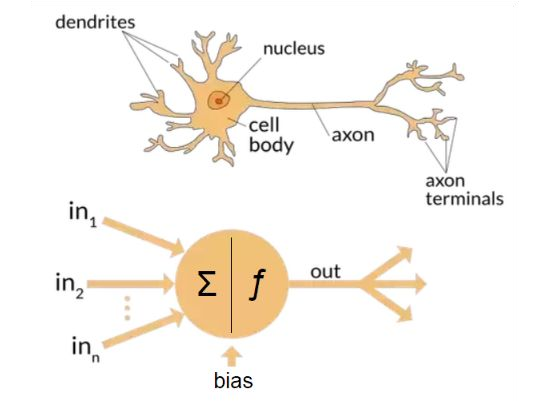

Top: a biological neuron. Bottom: its artificial counterpart with inputs, a weighted sum, an activation function and a bias.

| Biological neuron | Artificial neuron |
| --- | --- |
| Dendrites receive signals from other neurons | Inputs x1, x2, ..., xn receive numbers |
| Synapses have different strengths, which change as we learn | Weights w: how much each input matters; they are what gets learned |
| The cell body (soma) combines the incoming signals | A weighted sum of inputs plus a bias |
| It fires only if a threshold is reached | An activation function decides the output |
| The axon carries the signal to other neurons | The output is passed to the next layer |
| About 86 billion neurons with trillions of connections: extremely complex | A simple mathematical function; networks have millions of them, still far fewer than a brain |

The brain analogy is only loose inspiration. An artificial neuron is just a formula, and a neural network is just many of these formulas wired together. Do not expect it to work like a real brain.

One artificial neuron decides: "Take an umbrella?" For each input, 1 means yes.

Inputs: cloudy = 1, rain in the forecast = 1, travel by car = 1.

Weights: 1, 3 and -2. Bias: -1. The answer is yes if the sum is above 0.

Explanation

Multiply each input by its weight, and add the bias: 1 + 3 - 2 - 1 = 1.

The sum is above 0, so the answer is yes.

The forecast has the largest positive weight, so it pushes strongly toward yes. Travel by car has a negative weight, so it pushes toward no.

If there is no rain in the forecast, the sum is -2, and the answer is no.

## 8.3The perceptron: the building block

The perceptron is the simplest neural network: a single neuron that makes a yes/no decision. It is a **linear classifier**, meaning it separates two classes with a straight line (or flat plane).

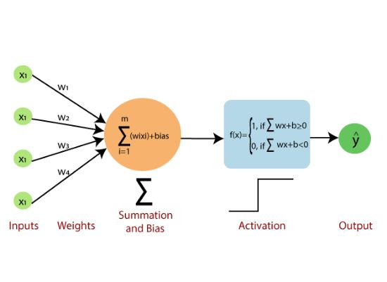

A perceptron: inputs x multiplied by weights w, summed with a bias, passed through an activation, giving output y-hat.

output = f( w1 x1 + w2 x2 + ... + wn xn + b )

### The four ingredients

- **Inputs (x):** the features of one example.
- **Weights (w):** one per input, saying how important that input is. A large positive weight pushes the neuron to fire (excitatory). A negative weight pushes against firing (inhibitory). A weight near zero means "ignore this input". Training changes the weights.
- **Bias (b):** a constant added to the sum. It shifts the point at which the neuron fires, exactly like the intercept c in the line y = mx + c. Without a bias, the decision boundary would be forced to pass through the origin, which severely limits what the neuron can learn.
- **Activation function (f):** converts the sum into the final output (step, sigmoid, ReLU).

**AND gate.** Choose w1 = 1, w2 = 1, bias b = -1.5, and the rule "output 1 if the sum is greater than 0".

| x1 | x2 | sum = x1 + x2 - 1.5 | output |
| --- | --- | --- | --- |
| 0 | 0 | -1.5 | 0 |
| 0 | 1 | -0.5 | 0 |
| 1 | 0 | -0.5 | 0 |
| 1 | 1 | 0.5 | 1 |

The neuron behaves as an AND gate. Notice the role of the bias: without it (b = 0), the input (1, 0) would give a sum of 1 and fire wrongly. The bias of -1.5 sets how much total evidence is needed before the neuron fires. In a real problem nobody picks these numbers by hand; the learning algorithm finds them from data.

### How a perceptron learns

It learns by correcting its mistakes. For each training example it makes a prediction, compares it with the true answer, and if it was wrong it nudges the weights: if it said 0 but the answer was 1, the weights of the active inputs go **up** so the sum is larger next time; if it said 1 but the answer was 0, they go **down**. This is written out as a program in the last chapter.

An OR gate gives 1 if at least one input is 1. Use w1 = 1, w2 = 1 and bias = -0.5. The output is 1 if the sum is above 0.

Explanation

Inputs (0, 0): the sum is -0.5, so the output is 0.

Inputs (0, 1) or (1, 0): the sum is 0.5, so the output is 1.

Inputs (1, 1): the sum is 1.5, so the output is 1.

The AND gate in this lesson has the same weights, but its bias is -1.5. So AND needs both inputs, but OR needs only one. The bias controls how easily the neuron gives 1.

## 8.4Why one neuron is not enough: the XOR problem

A single perceptron draws one straight line. That is enough for AND, but some problems cannot be split by any single line. The classic example is XOR ("exclusive or"), which outputs 1 only when the two inputs are **different**.

The fix is to add a **hidden layer**. One hidden neuron can learn "at least one input is on" and another "both inputs are on"; the output neuron then combines them as "the first but not the second". Several neurons together draw several lines and combine them into curved or complicated boundaries. This is the reason we need **multi-layer** (deep) networks.

XOR gives 1 only when the two inputs are different. We use three neurons. Each one gives 1 if its sum is above 0.

Neuron h1 uses x1 + x2 - 0.5. This answers: is at least one input 1?

Neuron h2 uses x1 + x2 - 1.5. This answers: are both inputs 1?

The output neuron uses h1 - h2 - 0.5.

Explanation

Inputs (0, 0): h1 = 0 and h2 = 0, so the output is 0.

Inputs (0, 1) or (1, 0): h1 = 1 and h2 = 0, so the output is 1.

Inputs (1, 1): h1 = 1 and h2 = 1, so the output is 0.

The last neuron means "at least one, but not both". The two hidden neurons turn the inputs into new facts that one final line can separate.

## 8.5Activation functions

After the neuron adds up its weighted inputs, the **activation function** transforms that sum into the neuron's output.

| Function | What it does | Where it is used and its weakness |
| --- | --- | --- |
| **Step** | outputs 0 or 1 at a threshold | the original perceptron; not smooth, so it cannot be trained by gradient descent |
| **Sigmoid** | squashes any number into the range 0 to 1 | output layer for yes/no problems, because the result reads as a probability. It flattens at both ends, so gradients become tiny (vanishing gradient) |
| **Tanh** | squashes into -1 to 1, centred on zero | hidden layers in older networks and in RNNs; also flattens at the ends |
| **ReLU** f(z) = max(0, z) | passes positive values unchanged and turns negative values to zero | the default for hidden layers: very cheap to compute and it does not flatten for positive values, so gradients survive. A neuron stuck outputting zero can stop learning |
| **Softmax** | turns a list of scores into probabilities that add up to 1 | output layer for many-class problems |

**Why do we need activation functions at all?** Without them, every layer would just multiply and add, and stacking such steps gives another multiply-and-add. Two layers W2 (W1 x) collapse into a single layer (W2 W1) x. A hundred layers would learn nothing that one layer could not: only straight lines. A non-linear activation between layers breaks this, allowing the network to bend its decision boundary and learn curved, complicated patterns. A second job is to control the output range (for example squeezing into 0 to 1 for a probability).

Network A has no activation function: h = 2x + 1, then y = 3h - 4.

Network B uses ReLU: y = ReLU(x) + ReLU(-x).

Explanation

In network A, put the first formula into the second: y = 3(2x + 1) - 4 = 6x - 1. The two layers do the work of one straight line.

In network B, the inputs -3, 0 and 3 give the outputs 3, 0 and 3. The graph has a V shape.

One straight line cannot make a V shape. ReLU makes this bend possible.

### Which one should I use?

- Hidden layers: **ReLU** (the default).
- Output layer, two classes: **sigmoid**. Many classes: **softmax**.
- Output layer for regression: no activation, so the output can be any number.

Give the values -2, 0 and 2 to different activation functions.

Sigmoid gives 0.12, 0.50 and 0.88.

Tanh gives -0.96, 0 and 0.96.

ReLU gives 0, 0 and 2.

Softmax changes the list of scores (2, 1, 0) into 0.67, 0.24 and 0.09.

Explanation

Sigmoid gives values between 0 and 1.

Tanh gives values between -1 and 1, with 0 in the middle.

ReLU changes negative values to 0 and keeps positive values.

Softmax uses the whole list together. The highest score gets the largest share. Before rounding, the shares add to 1.

## 8.6Neural network architecture: layers, weights and biases

A single neuron is weak, but thousands arranged in layers can learn remarkable things. The standard arrangement is called a **feed-forward network**: information flows in one direction, from the input to the output, with no loops.

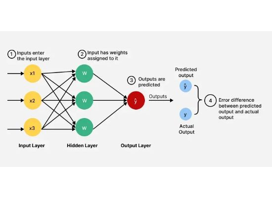

A feed-forward network: (1) inputs enter, (2) weights are applied, (3) the output is predicted, (4) the error against the actual output is measured.

[figure not shown]

Every neuron connects to every neuron in the next layer (a "fully connected" network).

- **Input layer:** one node per feature (three nodes for three features). It does no calculation; it only passes the data on.
- **Hidden layers:** the layers between input and output. They do the learning, building more complex patterns layer by layer. "Deep" means many hidden layers.
- **Output layer:** produces the prediction. A yes/no problem uses one node with sigmoid; a problem with ten classes uses ten nodes with softmax; a regression problem uses one node with no activation.
- **Weights and biases:** every connection has a weight and every neuron has a bias. These are the **parameters**, and they are exactly what training adjusts.

Counting parameters. For a network with 3, 4 and 2 neurons in successive layers: weights = 3 x 4 + 4 x 2 = 20 and biases = 4 + 2 = 6, so 26 parameters. Real networks have millions or billions, which is why they need large datasets and GPUs.

### Single-layer versus multi-layer

A **single-layer** network connects inputs straight to outputs, so it can only solve linearly separable problems. A **multi-layer** network has hidden layers and, together with non-linear activations, can learn complex relationships such as XOR.

A network has 4 inputs, 5 hidden neurons and 3 output neurons. Each neuron connects to all values in the layer before it.

Explanation

Weights from the inputs to the hidden layer: 4 x 5 = 20.

Weights from the hidden layer to the output layer: 5 x 3 = 15.

Each hidden neuron and each output neuron has one bias: 5 + 3 = 8. Inputs have no bias.

Total: 20 + 15 + 8 = 43 parameters.

## 8.7Forward propagation

Forward propagation (the forward pass) is how a network produces a prediction: the input is pushed through the layers, one after another.

At each layer: (1) take the outputs of the previous layer, (2) for each neuron compute the weighted sum plus bias, (3) apply the activation function, (4) hand the results to the next layer. When the output layer is reached, we have the prediction.

### Why matrix multiplication is central

A layer has many neurons, each doing the same kind of calculation. Instead of looping, we store all the layer's weights in a matrix W and write the whole layer in one line:

output = activation( W x input + b )

One matrix multiplication computes every neuron of the layer at the same time, and GPUs are built to do exactly this very fast. That is what makes training large networks practical.

Input x = (1, 2). Hidden neuron A has weights (0.5, -1) and bias 0.5; hidden neuron B has weights (1, 1) and bias 0; both use ReLU. The output neuron has weights (0.5, 0.2), bias 0.1 and sigmoid.

- A: 0.5 x 1 + (-1) x 2 + 0.5 = -1, and ReLU(-1) = 0.
- B: 1 x 1 + 1 x 2 + 0 = 3, and ReLU(3) = 3.
- Output sum: 0.5 x 0 + 0.2 x 3 + 0.1 = 0.7. Sigmoid(0.7) = 0.668.

The prediction is 0.668. If the true answer is 1, the squared error is (1 - 0.668)^2 = 0.11. This error is what the next step, backpropagation, uses to improve the weights.

One layer has two neurons. The input is x = (3, 1). The weight matrix (table of weights) W has the rows (1, 2) and (0, -1). The biases are (0, 2). The layer uses ReLU.

Explanation

Each row of W belongs to one neuron.

Neuron 1: 1 x 3 + 2 x 1 + 0 = 5.

Neuron 2: 0 x 3 + (-1) x 1 + 2 = 1.

ReLU keeps positive numbers, so the output is (5, 1).

One matrix calculation does the sums for all neurons in the layer.

## 8.8Training a network: the big picture

Training turns a network with random weights into a useful one. It is the same idea as gradient descent from the previous chapter, applied to every weight in the network.

1. Start with small random weights.
2. **Forward pass:** compute the prediction for a batch of examples.
3. **Loss:** compare the prediction with the true answer to get a single error number.
4. **Backward pass (backpropagation):** work out how much each weight contributed to the error (its gradient).
5. **Update:** change every weight slightly against its gradient.
6. Repeat for all batches, for many epochs, until the loss is low.

In ANN terminology, the **learning rule** is gradient descent (how weights are changed) combined with backpropagation (how the gradients are computed efficiently).

Why not search for good weights at random? A network may have millions of weights, so the number of combinations is astronomical. Gradient descent tells every weight, at once, which direction to move.

A network has only 100 weights. Each weight can have one of 10 values.

Explanation

The first weight has 10 choices. Two weights have 10 x 10 = 100 choices.

For 100 weights, there are 10 to the power 100 choices. This is a 1 followed by 100 zeros.

A computer cannot try them all in any practical time.

Gradient descent does not try every choice. It uses the current error to find a direction for all weights together. It does not always find the best weights.

A very small network is: prediction = w x. The input is x = 1, the correct answer is 2, and w starts at 0.5.

Explanation

1. Forward pass: the prediction is 0.5 x 1 = 0.5.

2. Loss: (0.5 - 2) squared = 2.25.

3. Gradient (slope of the loss): 2 x (0.5 - 2) x 1 = -3.

4. Update with learning rate 0.1: w = 0.5 - 0.1 x (-3) = 0.8.

The new loss is (0.8 - 2) squared = 1.44. It is lower than before. A large network repeats the same four steps with many weights.

## 8.9Backpropagation

Gradient descent needs the gradient of the loss with respect to **every** weight. For the output layer this is straightforward. But a weight deep inside the network affects the loss only indirectly, through all the layers after it. Backpropagation (short for "backward propagation of errors") is the efficient way to compute all these gradients.

### The two passes

1. **Forward pass:** input goes through the network to produce a prediction, and the loss is calculated.
2. **Backward pass:** starting at the output layer, the algorithm uses the **chain rule** of calculus to work out how much each weight and bias contributed to the error, moving layer by layer toward the input.

### The chain rule in everyday words

If a small change in weight A changes B, and a small change in B changes C, then the effect of A on C is (effect of A on B) multiplied by (effect of B on C). Backpropagation multiplies these effects along the path from the loss back to each weight. Each hidden neuron receives a share of the blame from the neurons it feeds, in proportion to the strength of its connections to them.

A tiny network with two weights in a row: h = w1 x and prediction = w2 h. Let x = 1, w1 = 2, w2 = 3 and the true answer y = 4. Loss = (prediction - y)^2.

- **Forward:** h = 2, prediction = 6, loss = (6 - 4)^2 = 4.
- **Backward, output first:** dLoss/dprediction = 2 x (6 - 4) = 4. Then dLoss/dw2 = 4 x h = 8.
- **Pass the blame back:** dLoss/dh = 4 x w2 = 12. Then dLoss/dw1 = 12 x x = 12.
- **Update** with learning rate 0.01: w2 = 3 - 0.01 x 8 = 2.92 and w1 = 2 - 0.01 x 12 = 1.88.
- **Check:** new h = 1.88, new prediction = 2.92 x 1.88 = 5.49, new loss = 2.22. The loss fell from 4 to 2.22.

Notice that w1 never saw the loss directly; it received its gradient through w2, passed backward. That is backpropagation.

Why go backward? The gradient for an early layer needs the gradients of all later layers. Going from the output backward lets us compute each piece once and reuse it, so the whole backward pass costs about the same as one forward pass. Doing it forward, weight by weight, would be hopelessly slow.

A network has 1,000,000 weights. We need to know how each weight affects the loss.

Explanation

A slow method changes one weight a little and runs the network again. It must do this for every weight, so it needs about 1,000,000 extra forward passes for one update.

Backpropagation starts at the output. It calculates each shared part once and uses it again for earlier layers.

It needs one forward pass and one backward pass. The backward pass costs a similar order of work as the forward pass.

### Updating the weights

Once backpropagation provides dL/dw for every weight, each is updated with the gradient descent rule: **w_new = w_old - learning rate x dL/dw**. This happens for all weights and biases in all layers at the end of each training step (for example, after each mini-batch).

A chain has three steps: h = 3w, then p = 2h, then loss = (p - 10) squared. We start with w = 1.

Explanation

Forward: h = 3, p = 6 and loss = 16.

Now go backward. A small change in p changes the loss -8 times as much.

A change in h changes p 2 times as much. A change in w changes h 3 times as much.

Multiply the three effects: -8 x 2 x 3 = -48. This is the gradient for w.

To test it, set w to 1.001. The loss becomes about 15.952. It falls by about 0.048, which matches -48 x 0.001.

## 8.10Convergence problems in training

Convergence means the loss settles at a low, stable value. Several things can prevent this.

| Problem | What happens | Common remedies |
| --- | --- | --- |
| Vanishing gradients | in deep networks the gradients shrink as they travel backward, so early layers barely change and learning stalls | ReLU activation, careful weight initialisation, LSTM, skip connections |
| Exploding gradients | gradients grow huge, weight updates become enormous and the loss turns into NaN (not a number) | gradient clipping, a smaller learning rate |
| Poor hyperparameters | learning rate too high or low, bad initial weights, unsuitable optimiser | tune on the validation set |
| Local minima and plateaus | the loss surface is bumpy, so training can settle in a poor valley or crawl across a flat region | mini-batch noise, momentum, the Adam optimiser |
| Hard data or weak model | the loss stays high however you tune | better data or a more suitable architecture |

**Why do gradients vanish?** By the chain rule, the gradient reaching an early layer is a product of many numbers, one per layer. If each is less than 1 the product collapses. The sigmoid's slope is at most 0.25, so ten sigmoid layers multiply to about 0.25 to the power 10, roughly 0.000001. The first layers receive almost no signal and cannot learn. ReLU has slope 1 for positive inputs, which is why it largely fixes the problem.

A message goes through four people. Each person keeps only 25 percent of its strength. The starting strength is 100.

Explanation

After each person, the strength is 25, then 6.25, then 1.56, then 0.39.

Almost nothing reaches the end of the line.

A gradient travels backward through layers in a similar way. The first layers are at the end of this path.

The slope of sigmoid is never above 0.25, so it can shrink the gradient quickly. Weights also affect the gradient. For positive inputs, the slope of ReLU is 1, so this slope does not shrink the gradient.

In a simple model, each layer multiplies the gradient by one number.

Case 1: multiply by 0.25 in each of 5 layers.

Case 2: multiply by 1.5 in each of 20 layers.

Explanation

Case 1 leaves about 0.001. The gradient is almost gone. This shows a vanishing gradient.

Case 2 gives about 3,300. The gradient is very large. This shows an exploding gradient.

The cause is repeated multiplication. In a real network, the number is different in each layer.

## 8.11Evaluating a network: reading the loss curves

While training we plot the loss against the number of epochs, for both the training data and the validation data. These two curves tell the whole story.

- **Healthy training:** both curves fall and end up close together.
- **Overfitting:** training loss keeps falling, but validation loss turns upward. The network is now memorising the training set rather than learning general patterns.
- **Underfitting:** both curves stay high; the network is too weak or training was too short.

**Remedies for overfitting:** **early stopping** (stop at the epoch where validation loss is lowest), more data, dropout, regularisation, or a smaller network.

These losses are made up. We record them after 10, 20, 30 and 40 epochs.

Training loss: 0.60, 0.40, 0.28, 0.20.

Validation loss: 0.65, 0.48, 0.45, 0.55.

Explanation

Up to epoch 30, both losses go down. The model gets better.

At epoch 40, the training loss is lower, but the validation loss is higher. This is a sign of overfitting.

Of these four points, keep the model from epoch 30. Real results go up and down, so wait for several worse results before you stop.

## 8.12Exam questions and model answers: Chapter 8

Q1. Compare a biological neuron with an artificial neuron.

A biological neuron receives signals through dendrites, sums them in the cell body, fires along the axon if a threshold is reached, and the strength of each synapse changes with learning. An artificial neuron receives numerical inputs, multiplies each by a weight (the synapse strength), adds a bias, and passes the sum through an activation function to give its output. The biological neuron is vastly more complex; about 86 billion neurons in the brain compared with a simple mathematical function in an ANN.

Q2. Describe the structure of an Artificial Neural Network.

An ANN has an input layer with one node per feature (no computation), one or more hidden layers that learn complex patterns (more than one makes it "deep"), and an output layer that gives the prediction; its size and activation depend on the task. Every connection carries a weight and every neuron a bias; these are the learnable parameters.

Q3. What is the significance of activation functions?

They introduce non-linearity. Without them any number of layers would be equivalent to a single linear model, so the network could not learn complex patterns. They also set the range of a neuron's output. Sigmoid gives 0 to 1 (probabilities), tanh gives -1 to 1, and ReLU gives max(0, z) and is the default for hidden layers because it is cheap and reduces vanishing gradients.

Q4. What are the effects of weights and bias?

A weight sets the strength and sign of an input's influence: large positive means strong excitation, negative means inhibition, near zero means little effect. The bias is a constant added to the weighted sum that shifts the activation function left or right, like the intercept in y = mx + c; without it the neuron's boundary would always pass through the origin.

Q5. What are the learning rules in an ANN?

The standard learning rule is gradient descent combined with backpropagation. Gradient descent adjusts the weights in the direction that reduces the loss most steeply; backpropagation efficiently computes the gradient of the loss for every weight by passing the error backward through the network.

Q6. What is forward propagation?

The process of computing the network's output for a given input by passing data layer by layer from the input to the output. At each layer, each neuron computes the weighted sum of its inputs plus bias and applies the activation function; the results become the next layer's inputs.

Q7. Describe the backpropagation algorithm and explain how the error propagates backward.

Backpropagation trains multi-layer networks in two phases. The forward pass computes the prediction and the loss. In the backward pass, starting at the output layer, the chain rule is applied to compute the partial derivative of the loss with respect to each weight and bias, layer by layer toward the input. Each hidden neuron receives a share of the error from the neurons it connects to, weighted by the connection strengths. These gradients are then used to update the weights.

Q8. How are weights updated in a multi-layer network?

After backpropagation gives dL/dw for each weight, every weight is updated using w_new = w_old - learning rate x dL/dw, for all weights and biases across all layers, typically at the end of each mini-batch.

Q9. What are the common convergence issues in training neural networks?

Vanishing gradients (early layers stop learning), exploding gradients (unstable, huge updates and NaN loss), poor hyperparameter choices such as the learning rate and initialisation, getting stuck in local minima or plateaus, and difficult data or an inadequate architecture.

Q10. Why is matrix multiplication fundamental in neural networks?

The weighted sums of all neurons in a layer can be computed with one matrix-vector multiplication, output = activation(W x input + b), which GPUs execute extremely fast in parallel. This makes training deep networks feasible.

Q11. What is the significance of the dot product in a neuron?

The dot product of the weight vector and the input vector is exactly the weighted sum inside a neuron. It also measures how similar two vectors are, which is used in many other methods.

Chapter 9

# Specialised Networks: CNN, RNN and LSTM

Architectures designed for images and for sequences.

## 9.1Convolutional Neural Networks (CNN)

A CNN is a network designed for **images** (and other grid-like data such as video frames and medical scans).

### Why not just use an ordinary network for pictures?

A small 224 by 224 colour photo has 224 x 224 x 3 = 150,528 numbers. One hidden layer of 1,000 neurons connected to every pixel would need over 150 million weights. That is wasteful, and it ignores the most important property of images: **nearby pixels belong together**, and a feature such as an edge looks the same wherever it appears. A CNN uses this structure.

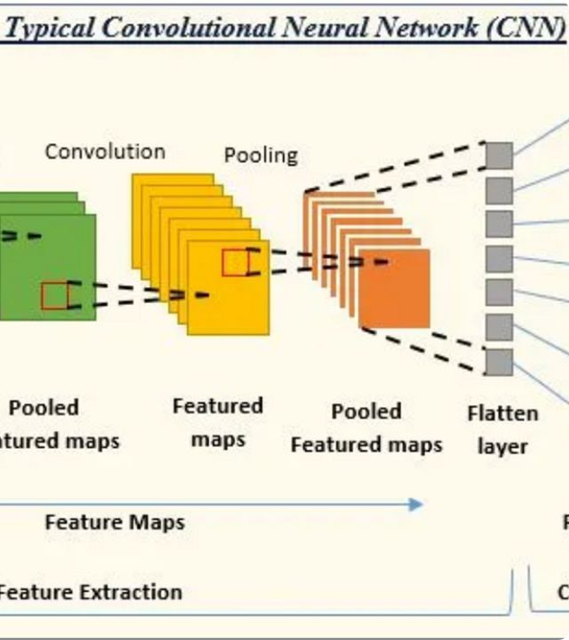

Typical CNN: convolution and pooling layers extract feature maps, then a flatten layer feeds the classifier.

### The building blocks

- **Convolution layer.** A small grid of weights called a **filter** (or kernel), for example 3 x 3, slides across the image. At each position it multiplies its weights with the pixels beneath it and adds them up, producing one number. The collection of these numbers is a **feature map** showing where in the image that pattern (an edge, a corner, a texture) was found. The **same filter is reused at every position**, so the layer needs only a handful of weights and detects the pattern anywhere in the picture. The filter values are learned during training.
- **Activation (ReLU)** is applied after convolution to add non-linearity.
- **Pooling layer.** Shrinks each feature map, for example by keeping only the maximum of each 2 x 2 block (**max pooling**). This cuts computation and makes the network tolerant to small shifts of the object in the picture.
- **Flatten and fully connected layers.** The final feature maps are laid out as a list and passed to ordinary layers that make the final decision, such as "cat" or "dog".

Early convolution layers find simple features (edges), later ones combine them into parts (eyes, wheels), and the last ones into whole objects. This is the "hierarchy of features" idea behind deep learning.

An image has 28 x 28 pixels and only gray shades. So it has 784 input values. We count the parameters of two layers.

A dense layer (every neuron sees every pixel) has 100 neurons.

A convolution layer has 32 filters of size 3 x 3.

Explanation

Dense layer: 784 x 100 weights + 100 biases = 78,500.

Convolution layer: each filter has 9 weights and 1 bias. So 32 x 10 = 320.

A filter uses the same weights at every place in the image. This is why the number is small.

The two layers give outputs of different sizes. The example compares only how they use weights.

## 9.2Worked example: convolution and pooling by hand

### Convolution

A 4 x 4 image: bright (9) on the left, dark (0) on the right, so there is a vertical edge in the middle.

```
9 9 0 0
9 9 0 0
9 9 0 0
9 9 0 0
```

A 2 x 2 filter, which compares the left column with the right column:

```
 1 -1
 1 -1
```

Slide it across, multiplying pairs and adding:

- Left position: 9x1 + 9x(-1) + 9x1 + 9x(-1) = 0 (both columns equally bright)
- Middle position: 9x1 + 0x(-1) + 9x1 + 0x(-1) = 18 (bright on the left, dark on the right: an edge)
- Right position: 0 (both dark)

Every row of the output is **0, 18, 0**. The large value marks exactly where the edge is.

### Max pooling (2 x 2)

```
1 3 | 2 1
4 6 | 5 2
----+----
3 1 | 0 7
2 8 | 9 4
```

Keep the largest number in each block:

```
6 5
8 9
```

The 4 x 4 map became 2 x 2, a quarter of the size, and the strongest responses survived.

**Why max?** We care whether the feature was detected somewhere in the block, not its exact position. That is what gives tolerance to small movements.

We want to find a horizontal edge.

The image rows are (5 5 5), (5 5 5) and (1 1 1).

The filter rows are (1 1) and (-1 -1).

Explanation

The filter adds two upper pixels and subtracts the two pixels below them.

On image rows 1 and 2: 5 + 5 - 5 - 5 = 0. The brightness does not change.

On image rows 2 and 3: 5 + 5 - 1 - 1 = 8. Here the brightness changes, so there is an edge.

The filter moves left to right too. The full result has the rows (0, 0) and (8, 8).

## 9.3Recurrent Neural Networks (RNN)

Some data comes in a **sequence** where order matters: sentences, speech, stock prices over time. The word "bank" means different things in "river bank" and "bank loan"; the meaning depends on the words around it. An ordinary network treats every input separately and has no memory, so it cannot use this context.

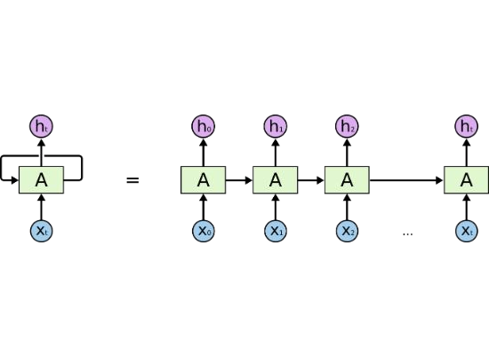

An RNN: the loop on the left, unrolled through time on the right. The same cell A is reused at every step.

An RNN adds **memory**. It reads the sequence one step at a time. At each step it combines the new input x with its **hidden state h**, which summarises everything seen so far, to produce a new hidden state. The same weights are used at every step, so the network can handle sequences of any length.

### The vanishing gradient problem in RNNs

To learn, the error must be passed backward through **every time step** (backpropagation through time). At each step the gradient is multiplied again by a number that is usually below 1, so after many steps it becomes almost zero. The RNN then cannot link something that happened long ago to something happening now. In "The cat, which had been sitting on the warm mat all afternoon, was hungry", a plain RNN has trouble remembering that the subject is "cat" by the time it reaches "was". It effectively **forgets early inputs**.

A very small RNN has one memory number, h. The rule is: new h = 0.5 x old h + input. At the start, h = 0.

Sequence A is 1, then 0. Sequence B is 0, then 1.

Explanation

Sequence A: h becomes 1, then 0.5.

Sequence B: h becomes 0, then 1.

Both sequences use the same numbers, but the final memory is different. So the order matters.

If sequence A gets one more 0, h falls to 0.25. The old input fades. A real RNN is more complex and learns its weights.

## 9.4Long Short-Term Memory (LSTM)

The LSTM is a special RNN designed to fix the vanishing gradient problem and remember over long spans.

The idea: give the network a separate **long-term memory**, the **cell state**, which passes along the sequence with only small, controlled changes. Three **gates** control it. Each gate is a small neural unit that outputs a number between 0 (block everything) and 1 (let everything through).

| Gate | Decides |
| --- | --- |
| **Forget gate** | which information from the old cell state to discard and which to keep |
| **Input gate** | which new information from the current input to write into the cell state |
| **Output gate** | which part of the cell state to send out as the hidden state for the next step |

Analogy: a notebook. The forget gate erases notes that are no longer useful, the input gate writes down what is important from today, and the output gate decides which notes to read out right now.

**Why does the LSTM remember better?** The cell state is mostly passed along unchanged, controlled by gates close to 1. Because information travels almost unchanged, the gradient can also flow backward over many steps without shrinking to nothing. That is how it solves the vanishing gradient problem.

We pass a memory value through 100 steps.

Case 1: keep 99 percent at each step.

Case 2: keep 50 percent at each step.

Explanation

In case 1, about 37 percent remains.

In case 2, the part that remains is almost zero.

When the forget gate is close to 1, the LSTM keeps most of the memory. The gradient on the same memory path also shrinks slowly.

The LSTM learns when to keep or forget. It reduces the vanishing gradient problem, but very long sequences can still be hard.

We follow one memory value through one LSTM step. The old memory is 10. The new candidate value is 4. The forget gate is 0.9, and the input gate is 0.5.

Explanation

The forget gate keeps 90 percent of the old memory: 0.9 x 10 = 9.

The input gate adds 50 percent of the new value: 0.5 x 4 = 2.

The new memory is 9 + 2 = 11.

The output gate controls what the cell shows. The cell first applies tanh, and tanh(11) is almost 1. With an output gate of 0.2, the output is about 0.2.

So the cell can store 11 but send out only a small value.

## 9.5Choosing the right network

| Network | Best for | Key idea | Example |
| --- | --- | --- | --- |
| Feed-forward (ANN) | tables of features | layers of weighted sums and activations | loan approval, fraud detection |
| CNN | images, video | shared sliding filters and pooling | face recognition, reading X-rays |
| RNN | short sequences, time series | hidden state acts as memory | sensor readings, simple text |
| LSTM | long sequences | gates control a long-term memory | translation, speech recognition |
| Transformer | language and more | attention: look directly at the relevant parts of the input | ChatGPT-style assistants |

Choose a network for each job:

1. Predict loan risk from a table with 12 columns.

2. Find a crack in a photo of a wall.

3. Predict the next sensor value from the last 10 values.

4. Translate a long paragraph.

Explanation

Good first choices are: feed-forward network for job 1, CNN for job 2, RNN for job 3 and Transformer for job 4.

The shape of the data guides the choice: a table, an image, a short sequence, or long text.

An LSTM can also do jobs 3 and 4. Today, Transformers are the usual choice for translation. For job 1, also compare a simpler ML model.

## 9.6Exam questions and model answers: Chapter 9

Q1. What is a CNN and where is it used? Explain convolution and pooling.

A Convolutional Neural Network is designed for image data. Convolution layers slide small filters (kernels) over the image to detect local features such as edges, corners and textures, producing feature maps; the same filter is reused across the image, which keeps the number of weights small. Pooling layers, for example max pooling, down-sample the feature maps, reducing dimensions and computation and making the model robust to small shifts of the object. CNNs are used for image classification, object detection and face recognition.

Q2. Why is a CNN preferred to an ordinary neural network for images?

An ordinary network would need a huge number of weights (millions per layer for a normal photo) and ignores the spatial structure of images. A CNN exploits local patterns and reuses filters, so it needs far fewer parameters and detects a feature wherever it appears.

Q3. What is an RNN? What is the vanishing gradient problem?

A Recurrent Neural Network processes sequential data step by step and keeps a hidden state that acts as memory of earlier inputs, so it suits text, speech and time series. The vanishing gradient problem occurs when gradients, propagated backward through many time steps, are repeatedly multiplied by small values and shrink toward zero; the network then forgets early inputs and cannot learn long-range dependencies.

Q4. How does LSTM solve the vanishing gradient problem?

An LSTM has a cell state that carries information along the sequence with minimal change, regulated by three gates. The forget gate discards unneeded information, the input gate stores new useful information, and the output gate chooses what to pass on as the hidden state. Because the cell state is largely preserved, gradients can flow back across many time steps without vanishing.

Q5. Name the key applications of deep learning.

Computer vision (image classification, object detection, face recognition) with CNNs; natural language processing (translation, sentiment analysis, chatbots) with RNNs, LSTMs and Transformers; and predictive analytics (stock forecasting, fraud detection, disease diagnosis).

Q6. Write the convolution of the image rows 9 9 0 0 (four identical rows) with the filter [1 -1; 1 -1].

Sliding the 2 x 2 filter gives 9(1) + 9(-1) + 9(1) + 9(-1) = 0 at the left, 9 - 0 + 9 - 0 = 18 in the middle, and 0 at the right, so each output row is 0, 18, 0. The high value marks the vertical edge between the bright and dark regions.

Chapter 10

# Revision Guide and Exam Preparation

Definitions, formulas, comparisons and answer-writing technique, plus the perceptron learning algorithm.

## 10.1The perceptron learning algorithm (logic of the program)

This is a frequently asked "write the logic" question. The perceptron learns by correcting its own mistakes.

1. **Initialise:** set every weight to zero or a small random number, set the bias to 0, and choose a small learning rate such as 0.1.
2. **Loop** over the training examples, for a fixed number of epochs or until no mistakes are made. For each example (inputs x, true label y):
   1. Calculate the sum: w1 x1 + w2 x2 + ... + bias.
   2. Apply the step function: predict 1 if the sum is greater than 0, otherwise 0.
   3. Calculate the error: error = y - prediction.
   4. If error is not zero, update: each weight w = w + learning rate x error x x, and bias = bias + learning rate x error.
3. **Predict** new data with the final weights and bias, using steps (a) and (b).

Why does the update fix the mistake? If the neuron predicted 0 but the answer was 1, the error is +1, so the weights of the active inputs increase and the sum is larger next time, pushing the output toward 1. If it predicted 1 but the answer was 0, the error is -1, the weights decrease and the sum falls. When the prediction is right the error is 0 and nothing changes.

The perceptron has weights (-1, 0) and bias 0. The learning rate is 0.5. The input is (1, 1), and the correct answer is 1.

Explanation

The sum is -1, so the prediction is 0. The sum is too low.

Error = 1 - 0 = +1.

The new weights are (-0.5, 0.5), and the new bias is 0.5.

The new sum is -0.5 + 0.5 + 0.5 = 0.5. The sum is above 0, so the prediction is now 1.

The update raised the sum for this input. This moved the output toward the correct answer.

Weights (0, 0), bias 0, learning rate 1. Example: x = (1, 1) with label y = 1. Sum = 0, so the prediction is 0 and the error is 1. Update: weights become (0 + 1x1x1, 0 + 1x1x1) = (1, 1) and the bias becomes 0 + 1x1 = 1. Check: the new sum is 1 + 1 + 1 = 3, which gives prediction 1. Correct.

The perceptron is guaranteed to find a solution only if the classes can be separated by a straight line. That is why it fails on XOR and why multi-layer networks with backpropagation were needed.

The perceptron has weights (1, 1) and bias 0. The learning rate is 0.5. The input is (1, 0), and the correct answer is 0.

Explanation

The sum is 1, so the prediction is 1. This is wrong.

Error = correct answer - prediction = 0 - 1 = -1.

The new weights are (0.5, 1), and the new bias is -0.5.

The new sum is 0. The rule gives 1 only for a sum above 0, so the prediction is now 0.

The second weight stays the same, because its input is 0. Sometimes one update is not enough.

## 10.2Definitions in one line

| Term | Definition |
| --- | --- |
| Artificial Intelligence | machines performing tasks that normally require human intelligence |
| Machine Learning | learning patterns from data to predict or decide without being explicitly programmed |
| Deep Learning | machine learning with neural networks of many layers that learn features automatically |
| Supervised learning | learning from labelled data; classification (category) and regression (number) |
| Unsupervised learning | finding structure in unlabelled data; clustering and dimensionality reduction |
| Reinforcement learning | an agent learning actions through rewards and penalties |
| Feature / label | an input property / the answer to be predicted |
| Parameter | a value learned from data during training (weights, biases) |
| Hyperparameter | a setting chosen before training (learning rate, K, tree depth) |
| Overfitting | memorising training data including noise: low training error, high test error |
| Underfitting | a model too simple to capture the pattern: high error on both |
| Generalisation | performing well on new, unseen data |
| Loss function | a number measuring how wrong the predictions are; training minimises it |
| Gradient descent | repeatedly stepping against the gradient of the loss to reduce it |
| Learning rate | the step size of gradient descent |
| Epoch | one complete pass through the training set |
| Backpropagation | computing each weight's gradient by passing the error backward through the network using the chain rule |
| Activation function | a function that adds non-linearity to a neuron's output |
| Vanishing gradient | gradients shrinking toward zero as they pass back through many layers or time steps |

## 10.3Formulas to remember

| Topic | Formula |
| --- | --- |
| Accuracy | (TP + TN) / (TP + TN + FP + FN) |
| Precision | TP / (TP + FP) |
| Recall | TP / (TP + FN) |
| F1-score | 2 x Precision x Recall / (Precision + Recall) |
| MAE | average of \|actual - predicted\| |
| MSE and RMSE | average of (actual - predicted) squared; RMSE is its square root |
| Min-Max scaling | (x - min) / (max - min) |
| Standardisation | (x - mean) / standard deviation |
| Weight update (gradient descent) | w_new = w_old - learning rate x gradient |
| Single neuron | output = f( w1 x1 + ... + wn xn + b ) |
| Layer of neurons | output = f( W x input + b ) |
| ReLU | f(z) = max(0, z) |
| Perceptron update | w = w + learning rate x error x x; b = b + learning rate x error |

## 10.4The most-asked comparisons

Examiners love "differentiate between" questions. For each, answer in a small table or in two parallel sentences, and add an example.

| Compare | Key difference |
| --- | --- |
| ML vs traditional programming | rules written by humans vs rules learned from data |
| AI vs ML vs DL | widest goal vs learning from data vs learning with many-layer neural networks |
| Supervised vs unsupervised | labelled data vs unlabelled data |
| Classification vs regression | predicts a category vs predicts a number |
| Batch vs online learning | all data at once, retrain from scratch vs incremental updates from a stream |
| Parameters vs hyperparameters | learned from data vs set before training |
| Underfitting vs overfitting | too simple (high bias) vs too complex (high variance) |
| Precision vs recall | correctness of flagged cases vs share of real cases found |
| Batch vs stochastic vs mini-batch GD | whole dataset vs one example vs a small group per update |
| Sigmoid vs ReLU | squashes to 0 to 1 and can cause vanishing gradients vs max(0, z), the default for hidden layers |
| Feed-forward network vs RNN | no memory, fixed input vs hidden-state memory for sequences |
| RNN vs LSTM | forgets long-range information vs gates preserve long-term memory |
| Biological vs artificial neuron | complex living cell vs a simple weighted-sum function |
| K-Means vs hierarchical vs DBSCAN | fixed K, round clusters vs a merge tree with no K needed vs density-based clusters of any shape |

## 10.5How to write a strong exam answer

1. **Start with a one-line definition** in your own words.
2. **Give the reason**: why does this exist, or what problem does it solve? This is where most marks are won.
3. **Add an example**: a spam filter, house price prediction, cancer screening. A concrete example shows understanding.
4. **Draw the diagram** when one exists: the nested AI-ML-DL circles, the confusion matrix, the gradient descent valley, the overfitting curves, the neural network layers, the workflow boxes.
5. **For "compare" questions** use a table with four or five rows.
6. **For "write the logic" questions** give numbered steps first (initialise, loop, update, stop).
7. **For numerical questions** write the formula, substitute the numbers, and state the final value.

### Examples that fit most answers

| Concept | Handy example |
| --- | --- |
| Classification | spam or not spam; diseased or healthy |
| Regression | house price; tomorrow's temperature |
| Clustering | grouping customers by buying behaviour |
| Overfitting | memorising the practice paper |
| When recall matters most | cancer screening (do not miss a patient) |
| When precision matters most | spam filter (do not hide an important email) |
| CNN | face recognition, medical image reading |
| RNN / LSTM | language translation, speech recognition, stock series |

## 10.6Self-test: try these without looking

1. Draw the relationship between AI, ML, DL and Data Science.

AI is the outermost region, ML sits inside AI, and Deep Learning sits inside ML. Data Science is drawn as an overlapping region because it uses ML and statistics as tools to extract insight from data.

2. A model has 99 percent training accuracy and 70 percent test accuracy. What is wrong, and what can you do?

It is overfitting: it has memorised the training data but does not generalise. Remedies are more data, a simpler model or fewer features, regularisation, cross-validation, early stopping, and dropout (in neural networks).

3. Why do we keep a test set that is never used during training?

So that we obtain an honest, unbiased estimate of how the model performs on new data. If the test data influenced training or tuning, the score would be optimistic because of data leakage.

4. Why do we subtract the gradient instead of adding it?

The gradient points in the direction in which the loss increases fastest. To reduce the loss we must move the opposite way, so we subtract it.

5. What happens if the learning rate is too large? Too small?

Too large: the steps overshoot the minimum, the loss oscillates or even grows (divergence). Too small: learning is very slow and may stall before reaching a good solution.

6. Why is a non-linear activation function necessary?

Without it, stacked layers collapse into one linear transformation, so the network could only learn straight-line relationships. Non-linearity lets it learn curved, complex patterns such as XOR.

7. Explain the forward pass and the backward pass in your own words.

The forward pass pushes the input through the layers to produce a prediction and compute the loss. The backward pass sends the error back from the output toward the input, using the chain rule to find how much each weight contributed to the error; the weights are then adjusted to reduce it.

8. What does pooling do, and why?

It reduces the size of feature maps (for example keeping the maximum in each block). This lowers computation and makes the network less sensitive to the exact position of a feature.

9. Why does an LSTM remember longer than a plain RNN?

Its cell state is passed along the sequence with little change, controlled by forget, input and output gates, so information and gradients survive across many time steps instead of vanishing.

10. A classifier gives TP = 40, FP = 10, FN = 20, TN = 30. Find accuracy, precision, recall and F1.

Accuracy = 70/100 = 0.70; precision = 40/50 = 0.80; recall = 40/60 = 0.667; F1 = 2 x 0.8 x 0.667 / (0.8 + 0.667) = 0.727.